# Disciplined Convex Optimization in R

Anqi Fu, Balasubramanian Narasimhan, Stephen Boyd

2021-07-23

# Introduction

Optimization problems are at the heart of statistical inference and machine learning, where a scalar criterion is either maximized (likelihood, for instance) or minimized (loss) to estimate a parameter of interest. Constraints might be added to narrow the search space or to ensure the solution has certain properties.

The kinds of optimization problems we address in this tutorial have the following form:
$$\begin{array}{lll} \text{minimize} & f_0(x) & \\
\text{subject to} & f_i(x) \leq 0, & i=1, \ldots, M\\
& Ax=b &
\end{array}$$
with variable $x \in {\mathbf R}^n$.

Further, we ask that

- the objective and inequality constraints $f_0, \ldots, f_M$ are convex: for all $x$, $y$, $\theta \in [0,1]$,
  $$\begin{equation}
  f_i(\theta x + (1-\theta) y) \leq \theta f_i(x) + (1-\theta) f_i(y)
  \end{equation}$$
  i.e., graphs of $f_i$ curve upward,
- the equality constraints are linear, i.e., they can be expressed as a simple matrix equation $Ax = b$.

Geometrically, a function is convex if the chord or line segment drawn from any point $(x, f(x))$ to another point $(y, f(y))$ lies above the graph of $f$, as shown below.

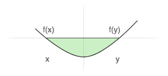

Source: https://www.solver.com

A function is concave if $-f$ is convex. Every linear function is both convex and concave.

Convex optimization problems have many nice properties:

- The region containing solutions, if any, is convex as it is the intersection of convex constraint functions.
- Since the objective is also convex, if we find a local optimal solution, it is automatically the global optimal solution.

There are a host of applications of this problem in many fields, including machine learning and statistics.

## Convex Problems in Statistics, Machine Learning

- Maximum likelihood estimation with constraints
- OLS regression, nonnegative least squares, logistic regression
- Ridge, lasso, elastic-net regression
- Isotonic regression
- Huber (robust) regression
- Support vector machine
- Sparse inverse covariance estimation
- Maximum entropy and related problems

New methods are being invented every year!

## Non-convex Problems

A non-convex optimization problem is any problem where the objective or any of the constraints are non-convex. Not every problem is convex, and in fact, the non-convex set is much larger. Non-convex problems are harder to solve in general.

However, even when a problem is non-convex, one may be able to find a convex *relaxation*, an approximation to the original problem, that can yield useful results. Thus, developing tools to solve convex problems can go a long way.

# Getting Started

The following are prerequisites.

- A recent R installation (version 3.5.x and up) will do. However, we highly recommend 4.0.5 so as to avoid any unforeseen problems with `CVXR`.
- [`CVXR`](https://cran.r-project.org/package=CVXR) version 1.0-9, which can be installed like any other package from [CRAN](https://cran.r-project.org).
- An IDE/editing environment such as [RStudio](https://rstudio.com), [Emacs](https://www.gnu.org/software/emacs/), or equivalent. If you use Emacs, we recommend the version packaged and distributed by [Vincent Goulet](https://vgoulet.act.ulaval.ca/en/home/) as it includes many useful modes. (We find, however, that recent versions of these Emacs binaries do not include `poly-R` or the `poly-markdown` packages by default; you’ll have to install them like any other Emacs package.)
- All the additional libraries that are used in this tutorial. The following code snippet in your R session will install them for you.

```r
required_packages  <- c("tidyr",
                        "ggplot2",
                        "nnls",
                        "ISLR",
                        "glmnet",
                        "isotone",
                        "profvis",
                        "dplyr",
                        "survey",
                        "expm",
                        "RColorBrewer",
                        "kableExtra")
install.packages(required_packages)
```

## Solver Prerequisites

`CVXR` comes with open source solvers, and most of the tutorial will use these *built-in* open source solvers. However, we will discuss use of commercial solvers, [MOSEK](https://www.mosek.com) and [GUROBI](https://www.gurobi.com) in particular. These are optional and not necessary for the tutorial.

If, however, you wish to follow along, you will need to install the (binary) solver packages provided by the vendors. Luckily, academic and evaluation single user licenses are available for free.

Ensure you have the R development tools installed: [Xcode](https://developer.apple.com/xcode/) on Macs, [Rtools](http://cran.r-project.org/bin/windows/Rtools/) on Windows.

### MOSEK

1. Follow the [general setup](https://docs.mosek.com/9.0/install/index.html) instructions.
2. Obtain an [evaluation or personal academic license](https://docs.mosek.com/9.0/licensing/quickstart.html#i-don-t-have-a-license-file-yet).
3. Follow the [instructions provided](https://docs.mosek.com/9.0/rmosek/install-interface.html#system-requirements) to install the `Rmosek` package.
4. Ensure that you can run any one of the [R examples](https://docs.mosek.com/9.0/rmosek/optimization-tutorials.html).

### GUROBI

1. Download [GUROBI optimizer version 9.1.2](http://www.gurobi.com/downloads/gurobi-optimizer). You will have to register for an account and accept the license agreement.
2. Obtain an [evaluation or academic license](http://www.gurobi.com/downloads/licenses/license-center).
3. Install the `gurobi` R package using [these instructions](https://www.gurobi.com/documentation/9.1/refman/ins_the_r_package.html).
4. Ensure that you can run any one of the [R examples](https://www.gurobi.com/documentation/9.1/examples/r_examples.html).

# Types of Convex Optimization Problems

Recall that a convex optimization problem is of the form
$$\begin{array}{lll} \text{minimize} & f_0(x) & \\
\text{subject to} & f_i(x) \leq 0, & i=1, \ldots, M \\
& Ax=b &
\end{array}$$
for $x \in {\mathbf R}^n$.

## Linear Programs

When the functions $f_i$ for all $i$ are linear in $x$, the problem is called a linear program. These are much easier to solve, and the celebrated work of [George Dantzig](https://en.wikipedia.org/wiki/George_Dantzig) resulted in the [*Simplex Algorithm*](https://en.wikipedia.org/wiki/Simplex_algorithm) for linear programs.

## Quadratic Programs

When the objective $f_0$ is quadratic in $x$ and $f_1,\ldots,f_M$ are linear in $x$, the problem is called a quadratic program.

## Cone Programs

When $f_i(x) \leq 0$ for all $i$ constrain $x$ to lie in a convex cone $C$, the problem is called a cone program. Examples of $C$ are the positive orthant $\mathbf{R}_+^n$, the set of positive semidefinite matrices $\{X \in \mathbf{R}^{n \times n}: X \succeq 0\}$, and the second-order cone $\{(x,t) \in \mathbf{R}^n \times \mathbf{R}: \|x\| \leq t\}$.

## Integer and Mixed Integer Programs

When all elements of $x$ are constrained to be integers, or even binary ($\{0,1\}$) values, the problem is called an integer program. If only a few elements of $x$ are constrained to be integers, then the problem is a mixed integer program. These problems are not convex, but can be relaxed (e.g., we replace $x \in \{0,1\}$ with $x \in [0,1]$).

# Solving Convex Problems

Although convex problems can look very difficult (nonlinear, even nondifferentiable), they can be solved very efficiently like a linear program. So, how does one solve such problems in R?

One possibility is to match the form of the problem to an existing solver routine. For example, the well-known [`optimx`](https://cran.r-project.org/package=optimx) package provides the following omnibus function:

```r
optimx(par, fn, gr=NULL, hess=NULL, lower=-Inf, upper=Inf,
            method=c("Nelder-Mead","BFGS"), itnmax=NULL, hessian=FALSE,
            control=list(),
             ...)
```

Here one has to specify a vector of initial parameters (`par`), the objective function (`fn`), optional gradient (`gr`) and Hessian functions (`hess`) depending on the method used, and upper and lower bounds for the solution. Obviously, the objective and the constraints must be supported by the `optimx` routines.

Another possibility is to use a package such as [`ROI`](https://cran.r-project.org/package=ROI), which provides interfaces to a number of solvers, including solvers for convex problems. It offers an object-oriented framework for defining optimization problems, but one still has to explicitly identify the type of every objective and constraint. If you can transform your problem into a cone program and use a standard cone program solver, then you can use `ROI` in a straightforward way.

## Verifying Convexity

Even before attempting a solution, one has to verify a problem is convex. A few possible approaches are to

- Directly apply the definition of a convex function
- Check first or second order conditions $\nabla^2{f}\succeq 0$. (These are often tedious and hard to derive)
- Construct $f_i$ out of a library of basic convex functions/atoms by combining them using calculus rules that preserve convexity, yielding a problem that is automatically convex

## Domain Specific Languages for Convex Optimization

Domain Specific Languages (DSLs) are specialized languages for a particular application, implemented in a general purpose programming language. They have become useful for expressing, manipulating, and solving problems in specific contexts: circuit design (VHDL), graph layout (DOT), data (XML), etc.

Over the last few years, specialized languages have become available for general convex optimization using the constructive approach discussed above.

- [CVX](https://cvxr.com/cvx/) and [YALMIP](https://yalmip.github.io), both implemented in MatLAB
- CVXPY implemented in Python
- Convex.jl implemented in Julia
- [CVXR](https://cvxr.rbind.io) implemented in R

Such DSLs may result in code that is slightly slower, but they are extremely flexible and enable fast prototyping of novel methods.

The last one, `CVXR`, is our focus and is described in a paper (Fu, B. Narasimhan, and Boyd 2020) that appears in the [Journal of Statistical Software](https://www.jstatsoft.org).

# Disciplined Convex Programming

> “All… new systems of notation are such that one can accomplish nothing by means of them which would not also be accomplished without them; but the advantage is that when such a system of notation corresponds to the innermost essence of frequently occuring needs, one can solve the problems belonging in that category, indeed can mechanically solve them in cases so complicated that without such an aid even the genius becomes powerless. Thus it is with the invention of calculating by letters in general; thus it was with the differential calculus…”

> —C. F. Gauss to Schumacher, May 15, 1843

> “That’s awesome! I was disappointed to not see a direct reference to DCP, but still, it’s pretty clear!”

> —Stephen Boyd, on Gauss’ letter to Schumacher, April 8, 2019

## Basic Convex Functions

The following are some basic convex functions.

- $x^p$ for $p \geq 1$ or $p \leq 0$; $-x^p$ for $0 \leq p \leq 1$
- $\exp(x)$, $-\log(x)$, $x\log(x)$
- $a^Tx + b$
- $x^Tx$; $x^Tx/y$ for $y>0$; $(x^Tx)^{1/2}$
- $\|x\|$ (any norm)
- $\max(x_1, x_2, \ldots, x_n)$, $\log(e^{x_1}+ \ldots + e^{x_n})$
- $\log(\Phi(x))$, where $\Phi$ is the Gaussian CDF
- $\log(\text{det}(X^{-1}))$ for $X \succ 0$

## Calculus Rules

- *Nonnegative Scaling*: if $f$ is convex and $\alpha \geq 0$, then $\alpha f$ is convex
- *Sum*: if $f$ and $g$ are convex, so is $f+g$
- *Affine Composition*: if $f$ is convex, so is $f(Ax+b)$
- *Pointwise Maximum*: if $f_1,f_2, \ldots, f_m$ are convex, so is $f(x) = \underset{i}{\max}f_i(x)$
- *Partial Minimization*: if $f(x, y)$ is convex and $C$ is a convex set, then $g(x) = \underset{y\in C}{\inf}f(x,y)$ is convex
- *Composition*: if $h$ is convex and increasing and $f$ is convex, then $g(x) = h(f(x))$ is convex

There are many other rules, but the above will get you far.

## Examples

- Piecewise-linear function: $f(x) = \underset{i}{\max}(a_i^Tx + b_i)$
- $l_1$-regularized least-squares cost: $\|Ax-b\|_2^2 + \lambda \|x\|_1$ with $\lambda \geq 0$
- Sum of $k$ largest elements of $x$: $f(x) = \sum_{i=1}^mx_i - \sum_{i=1}^{m-k}x_{(i)}$
- Log-barrier: $-\sum_{i=1}^m\log(−f_i(x))$ on $\{x \in \mathbf{R}^n : f_i(x) < 0\}$, where $f_i$ are convex
- Distance to convex set $C$: $f(x) = \text{dist}(x,C) =\underset{y\in C}{\inf}\|x-y\|_2$

Except for log-barrier, these functions are nondifferentiable.

# A Simple Regression Example

## Goals

- Basic introduction to `CVXR`
- Exercise on formulating a different objective, demonstrating how `CVXR` works with native R functions
- Exercises on formulating linear dependence constraints on estimates using linear algebra
- Exercises on formulating monotonicity constraints using `CVXR` atoms

## Ordinary Least-Squares Regression

Consider a simple linear regression problem, where it is desired to estimate a set of parameters using a least-squares criterion.

We generate some synthetic data in which we know the model completely, i.e.

$$Y = X\beta + \epsilon,$$

```r
set.seed(123)
n <- 50; p <- 10;
beta_true <- -4:5    # beta is just -4 through 5.
X <- matrix(rnorm(n * p), nrow=n)
colnames(X) <- paste0("beta_", beta_true)
Y <- X %*% beta_true + rnorm(n)
```

Given the data $X$ and $Y$, we can estimate the $\beta$ vector using the `lm` function in R, which fits a standard regression model.

```r
ls.model <- lm(Y ~ 0 + X)   # There is no intercept in our model above
m <- matrix(coef(ls.model), ncol = 1)
```

| $\beta_{1}$ | -3.9025328 |
| --- | --- |
| $\beta_{2}$ | -2.9683386 |
| $\beta_{3}$ | -1.8234267 |
| $\beta_{4}$ | -1.1562133 |
| $\beta_{5}$ | 0.0753986 |
| $\beta_{6}$ | 0.9224317 |
| $\beta_{7}$ | 1.8799511 |
| $\beta_{8}$ | 3.1107020 |
| $\beta_{9}$ | 4.1086503 |
| $\beta_{10}$ | 5.0947592 |

These are the least-squares estimates and can be seen to be reasonably close to the original $\beta$ values -4 through 5.

## The `CVXR` Formulation

The `CVXR` formulation states the above as an optimization problem:
$$\begin{array}{ll}
\underset{\beta}{\mbox{minimize}} & \|y - X\beta\|_2^2,
\end{array}$$
which directly translates into a problem that `CVXR` can solve as shown in the steps below.

- Step 0. Load the `CVXR` library

```r
library(CVXR, warn.conflicts=FALSE)
```

- Step 1. Define the variable to be estimated

```r
beta <- Variable(p)
```

- Step 2. Define the objective to be optimized

```r
objective <- Minimize(sum((Y - X %*% beta)^2))
```

Notice how the objective is specified using functions such as `sum`, `*%*`, and `^` that are familiar to R users despite the fact that `beta` is no ordinary R expression, but a `CVXR` expression.

- Step 3. Create a problem to solve

```r
problem <- Problem(objective)
```

- Step 4. Solve it!

```r
result <- solve(problem)
```

- Step 5. Examine solution status and obtain objective value and estimate

```
## OLS Solution Status: optimal, OLS Objective value: 34.134609
```

We can indeed satisfy ourselves that the results we get match those from `lm`.

```r
m <- cbind(result$getValue(beta), coef(ls.model))
```

|  | CVXR est. | lm est. |
| --- | --- | --- |
| $\beta_{1}$ | -3.9025328 | -3.9025328 |
| $\beta_{2}$ | -2.9683386 | -2.9683386 |
| $\beta_{3}$ | -1.8234267 | -1.8234267 |
| $\beta_{4}$ | -1.1562133 | -1.1562133 |
| $\beta_{5}$ | 0.0753986 | 0.0753986 |
| $\beta_{6}$ | 0.9224317 | 0.9224317 |
| $\beta_{7}$ | 1.8799511 | 1.8799511 |
| $\beta_{8}$ | 3.1107020 | 3.1107020 |
| $\beta_{9}$ | 4.1086503 | 4.1086503 |
| $\beta_{10}$ | 5.0947592 | 5.0947592 |

### Exercise

Modify the objective to perform least absolute deviation (LAD) regression and solve the problem. Compare the results to OLS. Which objective has a lower value?

*Hint*: In LAD regression, we minimize the sum of the absolute value of the residuals.

#### Solution

```r
objective2 <- Minimize(sum(abs(Y - X %*% beta)))
problem2 <- Problem(objective2)
result2 <- solve(problem2)
cat(sprintf("LAD Solution Status: %s, LAD Objective value: %f\n", result2$status, result2$value))
```

```
## LAD Solution Status: optimal_inaccurate, LAD Objective value: 31.270506
```

```r
m2 <- cbind(result2$getValue(beta), coef(ls.model))
```

|  | CVXR LAD est. | lm est. |
| --- | --- | --- |
| $\beta_{1}$ | -4.0291876 | -3.9025328 |
| $\beta_{2}$ | -2.8262793 | -2.9683386 |
| $\beta_{3}$ | -1.9491830 | -1.8234267 |
| $\beta_{4}$ | -1.1911186 | -1.1562133 |
| $\beta_{5}$ | 0.1912669 | 0.0753986 |
| $\beta_{6}$ | 0.9489240 | 0.9224317 |
| $\beta_{7}$ | 1.9297270 | 1.8799511 |
| $\beta_{8}$ | 3.0089938 | 3.1107020 |
| $\beta_{9}$ | 4.2534432 | 4.1086503 |
| $\beta_{10}$ | 5.0253611 | 5.0947592 |

```r
cat("LAD objective value: %f, OLS objective value: %f\n",
    result2$value, result$value)
```

```
## LAD objective value: %f, OLS objective value: %f
##  31.27051 34.13461
```

**N.B.** Note the reuse of `beta` in `objective2`. The value of `beta` will change depending on the problem context, and the function `result$getValue()` or `result2$getValue()` will account for the context as shown below.

```r
m3 <- cbind(result$getValue(beta), result2$getValue(beta))
```

|  | Problem 1 est. | Problem 2 est. |
| --- | --- | --- |
| $\beta_{1}$ | -3.9025328 | -4.0291876 |
| $\beta_{2}$ | -2.9683386 | -2.8262793 |
| $\beta_{3}$ | -1.8234267 | -1.9491830 |
| $\beta_{4}$ | -1.1562133 | -1.1911186 |
| $\beta_{5}$ | 0.0753986 | 0.1912669 |
| $\beta_{6}$ | 0.9224317 | 0.9489240 |
| $\beta_{7}$ | 1.8799511 | 1.9297270 |
| $\beta_{8}$ | 3.1107020 | 3.0089938 |
| $\beta_{9}$ | 4.1086503 | 4.2534432 |
| $\beta_{10}$ | 5.0947592 | 5.0253611 |

## Adding Constraints

On the surface, it appears that we have replaced one call to `lm` with at least five or six lines of new R code. On top of that, the code actually runs slower, so it is not clear what we really achieved.

However, suppose we knew that the $\beta$s were nonnegative and wished to take this fact into account in our model. This is [nonnegative least squares regression](https://en.wikipedia.org/wiki/Non-negative_least_squares), and `lm` would no longer do the job.

In `CVXR`, the modified problem merely requires the addition of a constraint to the problem definition.

```r
problem <- Problem(objective, constraints = list(beta >= 0))
result <- solve(problem)
betaEstimate <- result$getValue(beta)
```

| $\beta_{1}$ | 0.000000 |
| --- | --- |
| $\beta_{2}$ | 0.000000 |
| $\beta_{3}$ | 0.000000 |
| $\beta_{4}$ | 0.000000 |
| $\beta_{5}$ | 1.190672 |
| $\beta_{6}$ | 1.460162 |
| $\beta_{7}$ | 1.817840 |
| $\beta_{8}$ | 3.147380 |
| $\beta_{9}$ | 5.828936 |
| $\beta_{10}$ | 5.287308 |

We can verify once again that these values are comparable to those obtained from another R package, say [`nnls`](https://CRAN.R-project.org/package=nnls).

```r
nnls.fit <- nnls::nnls(X, Y)$x
m <- cbind(betaEstimate, nnls.fit)
```

|  | CVXR NNLS est. | nnls est. |
| --- | --- | --- |
| $\beta_{1}$ | 0.000000 | 0.000000 |
| $\beta_{2}$ | 0.000000 | 0.000000 |
| $\beta_{3}$ | 0.000000 | 0.000000 |
| $\beta_{4}$ | 0.000000 | 0.000000 |
| $\beta_{5}$ | 1.190672 | 1.190672 |
| $\beta_{6}$ | 1.460162 | 1.460162 |
| $\beta_{7}$ | 1.817840 | 1.817840 |
| $\beta_{8}$ | 3.147380 | 3.147380 |
| $\beta_{9}$ | 5.828936 | 5.828936 |
| $\beta_{10}$ | 5.287308 | 5.287308 |

### Exercise

Suppose it is known that $\sum_{i=1}^4\beta_i \leq 0$. Modify the original OLS problem to add this constraint.

#### Solution

The obvious solution is to add a constraint of the form

```r
constraint1 <- beta[1] + beta[2] + beta[3] + beta[4] <= 0
```

but it is generally easier working with matrices in `CVXR`, and so we construct a row vector with zeros everywhere except in positions 1 through 4.

```r
A <- matrix(c(rep(1, 4), rep(0, 6)), nrow = 1)
```

| $\beta_{1}$ | $\beta_{2}$ | $\beta_{3}$ | $\beta_{4}$ | $\beta_{5}$ | $\beta_{6}$ | $\beta_{7}$ | $\beta_{8}$ | $\beta_{9}$ | $\beta_{10}$ |
| --- | --- | --- | --- | --- | --- | --- | --- | --- | --- |
| 1 | 1 | 1 | 1 | 0 | 0 | 0 | 0 | 0 | 0 |

The sum constraint on $\beta$ is therefore
$$A\beta \leq 0$$
which we express in R as

```r
constraint1 <- A %*% beta <= 0
```

We are ready to solve the problem.

```r
problem <- Problem(objective, constraints = list(constraint1))
ex1 <- solve(problem)
```

And we can get the estimates of $\beta$.

```r
betaEstimate <- ex1$getValue(beta)
```

| $\beta_{1}$ | -3.9025328 |
| --- | --- |
| $\beta_{2}$ | -2.9683386 |
| $\beta_{3}$ | -1.8234267 |
| $\beta_{4}$ | -1.1562133 |
| $\beta_{5}$ | 0.0753986 |
| $\beta_{6}$ | 0.9224317 |
| $\beta_{7}$ | 1.8799511 |
| $\beta_{8}$ | 3.1107020 |
| $\beta_{9}$ | 4.1086503 |
| $\beta_{10}$ | 5.0947592 |

### Exercise

Add an additional constraint to the previous exercise that $\beta_i \leq 4$ for $i=5,\ldots,10$.

#### Solution

We create a diagonal matrix with ones along the diagonal entries $i=5,\ldots,10$.

```r
B <- diag(c(rep(0, 4), rep(1, 6)))
```

|  | $\beta_{1}$ | $\beta_{2}$ | $\beta_{3}$ | $\beta_{4}$ | $\beta_{5}$ | $\beta_{6}$ | $\beta_{7}$ | $\beta_{8}$ | $\beta_{9}$ | $\beta_{10}$ |
| --- | --- | --- | --- | --- | --- | --- | --- | --- | --- | --- |
| $\beta_{1}$ | 0 | 0 | 0 | 0 | 0 | 0 | 0 | 0 | 0 | 0 |
| $\beta_{2}$ | 0 | 0 | 0 | 0 | 0 | 0 | 0 | 0 | 0 | 0 |
| $\beta_{3}$ | 0 | 0 | 0 | 0 | 0 | 0 | 0 | 0 | 0 | 0 |
| $\beta_{4}$ | 0 | 0 | 0 | 0 | 0 | 0 | 0 | 0 | 0 | 0 |
| $\beta_{5}$ | 0 | 0 | 0 | 0 | 1 | 0 | 0 | 0 | 0 | 0 |
| $\beta_{6}$ | 0 | 0 | 0 | 0 | 0 | 1 | 0 | 0 | 0 | 0 |
| $\beta_{7}$ | 0 | 0 | 0 | 0 | 0 | 0 | 1 | 0 | 0 | 0 |
| $\beta_{8}$ | 0 | 0 | 0 | 0 | 0 | 0 | 0 | 1 | 0 | 0 |
| $\beta_{9}$ | 0 | 0 | 0 | 0 | 0 | 0 | 0 | 0 | 1 | 0 |
| $\beta_{10}$ | 0 | 0 | 0 | 0 | 0 | 0 | 0 | 0 | 0 | 1 |

So this new constraint is nothing but

```r
constraint2 <- B %*% beta <= 4
problem2 <- Problem(objective, constraints = list(constraint1, constraint2))
ex2 <- solve(problem2)
betaEstimate <- ex2$getValue(beta)
```

| $\beta_{1}$ | -4.0635639 |
| --- | --- |
| $\beta_{2}$ | -2.9932080 |
| $\beta_{3}$ | -1.9214633 |
| $\beta_{4}$ | -1.0858480 |
| $\beta_{5}$ | 0.0684279 |
| $\beta_{6}$ | 0.8810457 |
| $\beta_{7}$ | 1.8415355 |
| $\beta_{8}$ | 3.0255314 |
| $\beta_{9}$ | 4.0000000 |
| $\beta_{10}$ | 4.0000000 |

### Exercise

Solve the OLS regression problem under the constraint that the $\beta_i$ are nonnegative and monotonically nondecreasing.

*Hint*: What function in R computes lagged differences?

#### Solution

This requires some additional knowledge about R and `CVXR` functions. The `base::diff` generic function generates lagged differences of any order. `CVXR` provides a method for the generic. So the monotonicity constraint can be succinctly expressed as `diff(beta) >= 0`.

```r
problem3 <- Problem(objective,
                   constraints = list(beta >= 0, diff(beta) >= 0))
ex3 <- solve(problem3)
betaEstimate <- ex3$getValue(beta)
```

| $\beta_{1}$ | -0.0003094 |
| --- | --- |
| $\beta_{2}$ | -0.0001897 |
| $\beta_{3}$ | 0.0002098 |
| $\beta_{4}$ | 0.0001500 |
| $\beta_{5}$ | 1.1687435 |
| $\beta_{6}$ | 1.4481293 |
| $\beta_{7}$ | 1.8421746 |
| $\beta_{8}$ | 3.2337443 |
| $\beta_{9}$ | 5.5646969 |
| $\beta_{10}$ | 5.5646783 |

### Exercise

Fit OLS with just the following order constraints on $\beta$: $\beta_{i} \leq \beta_{i+1}$ for $i=1,\ldots, 4$ and $\beta_i \geq \beta_{i+1}$ for $i=5,\ldots,p$.

#### Solution

We have to combine all that we have learned earlier.

```r
D1 <- D2 <- diag(0, p)
D1[1:5, 1:5] <- 1; D2[5:p, 5:p] <- 1;
D3 <- D4 <- diag(0, p - 1)
D3[1:4, 1:4] <- 1; D4[5:(p-1), 5:(p-1)] <- 1;
constraints = list(D3 %*% diff(D1 %*% beta) >= 0, D4 %*% diff(D2 %*% beta) <= 0)
problem4 <- Problem(objective, constraints)
ex4 <- solve(problem4)
betaEstimate <- ex4$getValue(beta)
```

| $\beta_{1}$ | -3.9025328 |
| --- | --- |
| $\beta_{2}$ | -2.9683386 |
| $\beta_{3}$ | -1.8234267 |
| $\beta_{4}$ | -1.1562133 |
| $\beta_{5}$ | 0.0753986 |
| $\beta_{6}$ | 0.9224317 |
| $\beta_{7}$ | 1.8799511 |
| $\beta_{8}$ | 3.1107020 |
| $\beta_{9}$ | 4.1086503 |
| $\beta_{10}$ | 5.0947592 |

## Summary

- `CVXR`’s chief advantage is *flexibility*. Users can quickly modify and re-solve a problem, which is ideal for prototyping and experimenting with new statistical methods.
- `CVXR` syntax is simple and mathematically intuitive.
- `CVXR` combines seamlessly with native R code as well as several popular packages, allowing it to be incorporated easily into a larger analytical framework.

The user is free to construct statistical estimators that are solutions to a convex optimization problem where there may not be a closed form solution or even an implementation. Later, we will see how such solutions can be used with resampling techniques like the bootstrap to estimate variability.

The list of atoms provided by `CVXR` is documented [here](https://cvxr.rbind.io/cvxr_functions/)

# How `CVXR` Works

Let us consider the nonnegative least squares regression example once again.

```r
beta <- Variable(p)
objective <- Minimize(sum((Y - X %*% beta)^2))
constraints <- list(beta >= 0)
problem <- Problem(objective, constraints)
result <- solve(problem)
solution_status <- result$status
objective_value <- result$value
beta_hat <- result$getValue(beta)
```

## Variables

The `CVXR::Variable` function constructs an S4 class describing the argument of an optimization problem.

- `Variable()` specifies a 1-vector, essentially a scalar
- `Variable(m)` specifies an $m$-vector
- `Variable(m, n)` specifies an $m\times n$ matrix

There are also S4 classes representing certain special constructs such as semidefinite matrices as we shall see later.

## Objectives, Constraints, and Problems

The objective function should yield a scalar value. `CVXR` provides the `Minimize` and `Maximize` functions that take an `Expression` (another S4 class) as an argument. Standard arithmetic and generics are overloaded so that one may use any R function in the construction.

Constraints are specified as a list. One may construct this list directly or via some iterative computation, once again using various R and `CVXR` functions in the process.

In the above problem, the objective is

```r
objective <- Minimize(sum((Y - X %*% beta)^2))
```

which uses the `CVXR::Minimize` function along with standard R functions such as `sum` and squaring. This allows one to seamlessly work with all standard R constructs. However, the same objective may also be specified as

```r
objective <- Minimize(sum_squares(Y - X %*% beta))
```

using the `CVXR::sum_squares` function. As you use `CVXR` more and more, you will need to refer to the [`CVXR` functions list](https://cvxr.rbind.io/cvxr_functions/) to learn about these built-in functions.

A problem takes an objective and an optional constraint. It serves as the complete representation of the problem along with associated data, like the `Y` and `X` in the code snippet above.

## Solving the Problem

Calling the `solve` function on a problem sets several things in motion.

1. The problem is verified for convexity. If it is not convex, the solve attempt fails with an error message and a non-optimal status.
2. The problem along with the data is converted into a canonical form.
3. The problem is analyzed and classified according to its type: LP, QP, SDP, etc.
4. Among the available solvers, a suitable one is chosen that can handle the problem. Three open source solvers are built-in: Embedded Conic Solver (ECOS), Splitting Conic Solver (SCS), and Operator Splitting Quadratic Program Solver (OSQP), but there is also support for commercial solvers.
5. The canonicalized data structures (matrices, cone dimensions) along with solver options, if any, are dispatched to the solver in appropriate form.
6. Finally, the results from the solver along with some accessor functions for retrieving the solution and other quantities in the context of the solved problem are prepared and returned to the caller.

There are several modes of failure that can occur. The problem may not be convex, and that is indicated via an error message. However, even when the problem is convex, the solver may not converge to a solution. The latter could be due to a number of reasons: tight tolerances, too few iterations, numerical issues, etc. Therefore, the solution status should always be examined.

One option that can be very useful is verbosity, and this is specified by simply passing another parameter to `CVXR::solve`.

```r
result <- solve(problem, verbose = TRUE)
```

```
## -----------------------------------------------------------------
##            OSQP v0.6.0  -  Operator Splitting QP Solver
##               (c) Bartolomeo Stellato,  Goran Banjac
##         University of Oxford  -  Stanford University 2019
## -----------------------------------------------------------------
## problem:  variables n = 60, constraints m = 51
##           nnz(P) + nnz(A) = 604
## settings: linear system solver = qdldl,
##           eps_abs = 1.0e-05, eps_rel = 1.0e-05,
##           eps_prim_inf = 1.0e-04, eps_dual_inf = 1.0e-04,
##           rho = 1.00e-01 (adaptive),
##           sigma = 1.00e-06, alpha = 1.60, max_iter = 10000
##           check_termination: on (interval 25),
##           scaling: on, scaled_termination: off
##           warm start: on, polish: on, time_limit: off
##
## iter  objective    pri res    dua res    rho        time
##    1   0.0000e+00   3.23e+01   2.20e+04   1.00e-01   1.03e-04s
##   50   3.4135e+01   2.51e-07   2.97e-07   1.20e-02   2.05e-04s
## plsh   3.4135e+01   5.80e-15   1.12e-14  ---------   2.76e-04s
##
## status:               solved
## solution polish:      successful
## number of iterations: 50
## optimal objective:    34.1346
## run time:             2.76e-04s
## optimal rho estimate: 4.33e-03
```

## Solver Options

Solver options are unique to the chosen solver, so any arguments to `CVXR::solve` besides those documented [here](https://www.cvxgrp.org/CVXR/reference/psolve.html) are simply passed along to the solver. The reference for the specific solver must be consulted to set these options.

# Logistic Regression

## Goals

- Formulate the logistic regression likelihood function using `CVXR` atoms
- Example comparing `CVXR` results with R results from `glm`
- Exercise on extracting fitted values from `CVXR` logistic fit using lexically scoped `CVXR` facilities

## Logistic Regression Problem

In logistic regression (James et al. 2013), the response $y_i$ is binary: 0 or 1. (In a classification setting, the values of the response would represent class membership in one of two classes.) The conditional response given covariates $x$ is modeled as

$$y|x \sim \mbox{Bernoulli}(g_{\beta}(x)),$$

where $g_{\beta}(x) = \frac{1}{1 + e^{-x^T\beta}}$ is the logistic function. We want to maximize the log-likelihood function, yielding the optimization problem

$$\begin{array}{ll}
\underset{\beta}{\mbox{maximize}} & \sum_{i=1}^m \{
y_i\log(g_{\beta}(x_i)) + (1-y_i)\log(1 - g_{\beta}(x_i)) \}.
\end{array}$$

One may be tempted to use `log(1 + exp(X %*% beta))` as in conventional `R` syntax. However, this representation of $f(z)$ violates the DCP composition rule, so the `CVXR` parser will reject the problem even though the objective is convex. Users who wish to employ a function that is convex, but not DCP compliant should check the documentation for a custom atom or consider a different formulation.

`CVXR` provides the [`logistic` atom](https://cvxr.rbind.io/cvxr_functions/) as a shortcut for $f(z) = \log(1 + e^z)$.

## Example

We use example 4.6.2 of (James et al. 2013) with the `Smarket` data where a `glm` is fit as follows.

```r
library(ISLR)
data(Smarket)
glmfit <- stats::glm(formula = Direction ~ Lag1 + Lag2 + Lag3 + Lag4 + Lag5 + Volume,
                     data = Smarket, family = binomial)
```

The `CVXR` formulation merely has to specify the objective after setting up the data matrices appropriately.

```r
y <- as.integer(Smarket$Direction) - 1L
X <- cbind(1, as.matrix(Smarket[, c("Lag1", "Lag2", "Lag3", "Lag4", "Lag5", "Volume")]))
p <- ncol(X)
beta <- Variable(p)
objective <- -sum(X[y <= 0, ] %*% beta) - sum(logistic(-X %*% beta))
problem <- Problem(Maximize(objective))
result <- solve(problem)
beta_hat <- result$getValue(beta)
```

We can compare with the standard `stats::glm` estimate.

|  | CVXR | GLM |
| --- | --- | --- |
| $\beta_{0}$ | -0.1260091 | -0.1260003 |
| $\beta_{1}$ | -0.0730788 | -0.0730737 |
| $\beta_{2}$ | -0.0423043 | -0.0423013 |
| $\beta_{3}$ | 0.0110857 | 0.0110851 |
| $\beta_{4}$ | 0.0093595 | 0.0093589 |
| $\beta_{5}$ | 0.0103137 | 0.0103131 |
| $\beta_{6}$ | 0.1354496 | 0.1354407 |

## Exercise

Standard `stats::glm` returns an object that has fitted values: `glmfit$fitted.values`. How would you compute the fitted values from `CVXR`?

*Hint:* The `result$getValue()` evalutes expressions in the problem context.

### Solution

A key feature of `CVXR` is that it exploits lexical scoping built into R. So one can evaluate various functions of the variables that are solutions to the optimization problem.

The fitted values can be computed using

```r
fitted_values <- 1 / (1 + exp(result$getValue(-X %*% beta)))
```

We can also satisfy ourselves that the fitted values match the `glm` estimate, by computing the sum of squared differences.

```r
sum((fitted_values - glmfit$fitted.values))^2
```

```
## [1] 1.779124e-06
```

Similarly, the log-odds, $X\hat{\beta}$ , where $\hat{\beta}$ is the logistic regression estimate, can be computed as follows.

```r
log_odds <- result$getValue(X %*% beta)
```

# Isotonic Regression

## Goals

- Formulate the isotonic regression objective using some new `CVXR` atoms
- Compare with results from `isotone` package
- Exercise on handling ties, the secondary method of `isotone`, using `CVXR` atoms
- Exercise on handling ties, the tertiary method of `isotone`, using `CVXR` atoms

## Pituitary Data Example

[Isotonic regression](https://en.wikipedia.org/wiki/Isotonic_regression) is regression with monotonicity constraints. There are several packages in R to fit isotonic regression models. In this example, we consider [`isotone`](https://cran.r-project.org/package=isotone), which uses a pooled-adjacent-violators algorithm (PAVA) and active set methods to perform the fit.

We will use data from the `isotone` package (de Leeuw, Hornik, and Mair 2009) on the size of pituitary fissures for 11 subjects between 8 and 14 years of age.

```r
data("pituitary")
str(pituitary)
```

```
## 'data.frame':    11 obs. of  2 variables:
##  $ age : num  8 8 8 10 10 10 12 12 12 14 ...
##  $ size: num  21 23.5 23 24 21 25 21.5 22 19 23.5 ...
```

Since the size is expected to increase with age, an isotonic fit is suggested, so we fit using the `isotone` package.

```r
res_p <- with(pituitary, gpava(age, size))
```

The `CVXR` formulation expresses this pretty much in the mathematical form. We define a variable `x` of size `n`, the number of observations. The objective to be minimized is the least-squares error (`cvxr_norm`), yet another way of specifying least-squares loss. The monotonicity is specified using the `diff` function.

### Exercise

Can you explain why `CVXR` provide functions such as `cvxr_norm` and `p_norm` rather than just plain `pnorm`?

#### Solution

```r
x_p <- with(pituitary, {
      n <- length(size)
      x <- Variable(n)
      objective <- Minimize(cvxr_norm(size - x, 2))
      constraint <- list(diff(x) >= 0)
      problem <- Problem(objective, constraint)
      result <- solve(problem)
      result$getValue(x)
})
```

As the output below shows, the results are very close.

```r
print_matrix(cbind(res_p$x, x_p), col_names = c("isotone", "CVXR"))
```

| isotone | CVXR |
| --- | --- |
| 21.000 | 20.99998 |
| 22.375 | 22.37500 |
| 22.375 | 22.37500 |
| 22.375 | 22.37500 |
| 22.375 | 22.37500 |
| 22.375 | 22.37500 |
| 22.375 | 22.37500 |
| 22.375 | 22.37500 |
| 22.375 | 22.37500 |
| 23.500 | 23.50001 |
| 25.000 | 24.99999 |

## Handling Ties

Package `isotone` provides additional methods for handling tied data besides the default `ties = "primary"` method; `ties = "secondary"` enforces equality within ties, and `ties = "tertiary"` enforces monotonicity on the means. (The latter may cause individual fits to be non-monotonic.)

```r
res_s <- with(pituitary, gpava(age, size, ties = "secondary"))
res_t <- with(pituitary, gpava(age, size, ties = "tertiary"))
```

### Exercise

Implement the secondary method of ties using `CVXR` and compare the results with the `isotone` package.

#### Solution

The secondary method for ties just requires an additional constraint to enforce equality within tied values. We do this below by figuring out the tied observation indices using `base::split` and forcing those `x` values to be equal (i.e. `diff` == 0).

```r
x_s <- with(pituitary, {
    n <- length(size)
    x <- Variable(n)
    objective <- Minimize(p_norm(size - x, 2))
    secondary_constraints <- lapply(base::split(x = seq_len(n),
                                                f = age),
                                    function(i) diff(x[i]) == 0)
    constraint <- c(diff(x) >= 0,
                    secondary_constraints)
    problem <- Problem(objective, constraint)
    solve(problem)$getValue(x)
})
```

Here’s the comparison table.

| Isotone (S) | CVXR (S) |
| --- | --- |
| 22.22222 | 22.22222 |
| 22.22222 | 22.22222 |
| 22.22222 | 22.22222 |
| 22.22222 | 22.22222 |
| 22.22222 | 22.22222 |
| 22.22222 | 22.22222 |
| 22.22222 | 22.22222 |
| 22.22222 | 22.22222 |
| 22.22222 | 22.22222 |
| 24.25000 | 24.25001 |
| 24.25000 | 24.25001 |

### Exercise

Implement the tertiary method for ties using `CVXR` and compare with the `isotone` package.

#### Solution

The tertiary method requires computing the block means for use in enforcing monotonicity. We call the [`CVXR::vstack`](https://cvxr.rbind.io/cvxr_functions/) function to create a single vector of the block means.

Basically, `CVXR::hstack` is the equivalent of `base::cbind` and `CVXR::vstack` is the equivalent of `base::rbind`.

```r
x_t <- with(pituitary, {
    n <- length(size)
    x <- Variable(n)
    objective <- Minimize(p_norm(size - x, 2))
    blocks <- base::split(x = seq_len(n),
                          f = pituitary$age)
    block_means <- lapply(blocks, function(i) {
        v <- numeric(n)
        v[i] <- 1.0 / length(i)
        matrix(v, nrow = 1) %*% x
    })
    block_mean_vector <- do.call(vstack, block_means)
    constraint <- list(diff(block_mean_vector) >= 0)
    problem <- Problem(objective, constraint)
    solve(problem)$getValue(x)
})
```

Here’s the comparison table.

| Isotone (T) | CVXR (T) |
| --- | --- |
| 20.72222 | 20.72224 |
| 23.22222 | 23.22224 |
| 22.72222 | 22.72224 |
| 22.88889 | 22.88890 |
| 19.88889 | 19.88890 |
| 23.88889 | 23.88890 |
| 22.88889 | 22.88890 |
| 23.38889 | 23.38890 |
| 20.38889 | 20.38890 |
| 23.50000 | 23.49994 |
| 25.00000 | 24.99994 |

# Lasso and Elastic Net

## Goals

- Formulate lasso and elastic net regression models
- Compare with results from `glmnet` package
- Use loss functions besides squared loss with elastic net penalty

## Regularized Regression

Often in applications, we encounter problems that require regularization to prevent overfitting, introduce sparsity, facilitate variable selection, or impose prior distributions on parameters. Two of the most common regularization functions are the $l_1$-norm and squared $l_2$-norm, combined in the elastic net regression model (H. Zou (2005) and Friedman, Hastie, and Tibshirani (2010)).

$$\begin{array}{ll}
\underset{\beta}{\mbox{minimize}} & \frac{1}{2m}\|y - X\beta\|_2^2 +
\lambda(\frac{1-\alpha}{2}\|\beta\|_2^2 + \alpha\|\beta\|_1).
\end{array}$$

Here $\lambda \geq 0$ is the overall regularization weight and $\alpha \in [0,1]$ controls the relative $l_1$ versus squared $l_2$ penalty. Thus, this model encompasses both ridge ($\alpha = 0$) and lasso ($\alpha = 1$) regression.

It is convenient to define a function that calculates just the regularization term given the variable and penalty parameters. This modular approach will allow us to easily incorporate elastic net regularization into other regression models as we will see below.

```r
#' Define the elastic penalty
#' @param beta the arg min variable
#' @param lambda the penalization parameter
#' @param alpha the elastic net parameter, 0 = ridge, 1 = lasso
elastic_penalty <- function(beta, lambda = 0, alpha = 0) {
    ridge <- (1 - alpha) / 2 * sum_squares(beta)
    lasso <- alpha * cvxr_norm(beta, 1)
    lambda * (lasso + ridge)
}
```

## Example

We generate some synthetic sparse data for this example.

```r
## Problem data
set.seed(4321)
p <- 10
n <- 500
DENSITY <- 0.25    # Fraction of non-zero beta
beta_true <- matrix(rnorm(p), ncol = 1)
idxs <- sample.int(p, size = floor((1 - DENSITY) * p), replace = FALSE)
beta_true[idxs] <- 0
sigma <- 45
X <- matrix(rnorm(n * p, sd = 5), nrow = n, ncol = p)
eps <- matrix(rnorm(n, sd = sigma), ncol = 1)
Y <- X %*% beta_true + eps
```

We fit the elastic net model for several values of $\lambda$.

```r
TRIALS <- 10
beta_vals <- matrix(0, nrow = p, ncol = TRIALS)
lambda_vals <- 10^seq(-2, log10(50), length.out = TRIALS)
```

```r
beta <- Variable(p)
loss <- sum_squares(Y - X %*% beta) / (2 * n)
## Elastic-net regression LASSO
alpha <- 1
beta_vals <- sapply(lambda_vals,
                    function (lambda) {
                        obj <- loss + elastic_penalty(beta, lambda, alpha)
                        prob <- Problem(Minimize(obj))
                        result <- solve(prob)
                        result$getValue(beta)
                    })
```

We can now get a table of the coefficients.

|  | $\lambda = 0.010$ | $\lambda = 0.026$ | $\lambda = 0.066$ | $\lambda = 0.171$ | $\lambda = 0.441$ | $\lambda = 1.135$ | $\lambda = 2.924$ | $\lambda = 7.533$ | $\lambda = 19.408$ | $\lambda = 50.000$ |
| --- | --- | --- | --- | --- | --- | --- | --- | --- | --- | --- |
| $\beta_{1}$ | 0.891 | 0.890 | 0.888 | 0.883 | 0.870 | 0.836 | 0.747 | 0.553 | 0.038 | 0 |
| $\beta_{2}$ | 0.040 | 0.040 | 0.039 | 0.036 | 0.028 | 0.009 | 0.000 | 0.000 | 0.000 | 0 |
| $\beta_{3}$ | 0.301 | 0.300 | 0.299 | 0.294 | 0.283 | 0.254 | 0.181 | 0.000 | 0.000 | 0 |
| $\beta_{4}$ | -0.579 | -0.578 | -0.576 | -0.572 | -0.561 | -0.533 | -0.458 | -0.265 | 0.000 | 0 |
| $\beta_{5}$ | 0.386 | 0.385 | 0.384 | 0.380 | 0.371 | 0.347 | 0.283 | 0.114 | 0.000 | 0 |
| $\beta_{6}$ | 1.538 | 1.538 | 1.536 | 1.531 | 1.519 | 1.487 | 1.403 | 1.186 | 0.627 | 0 |
| $\beta_{7}$ | 0.181 | 0.180 | 0.178 | 0.174 | 0.163 | 0.136 | 0.065 | 0.000 | 0.000 | 0 |
| $\beta_{8}$ | -0.134 | -0.134 | -0.132 | -0.127 | -0.114 | -0.082 | 0.000 | 0.000 | 0.000 | 0 |
| $\beta_{9}$ | 0.939 | 0.938 | 0.936 | 0.931 | 0.918 | 0.885 | 0.794 | 0.570 | 0.026 | 0 |
| $\beta_{10}$ | -0.329 | -0.328 | -0.327 | -0.322 | -0.312 | -0.284 | -0.215 | -0.030 | 0.000 | 0 |

We plot the coefficients against the regularization.

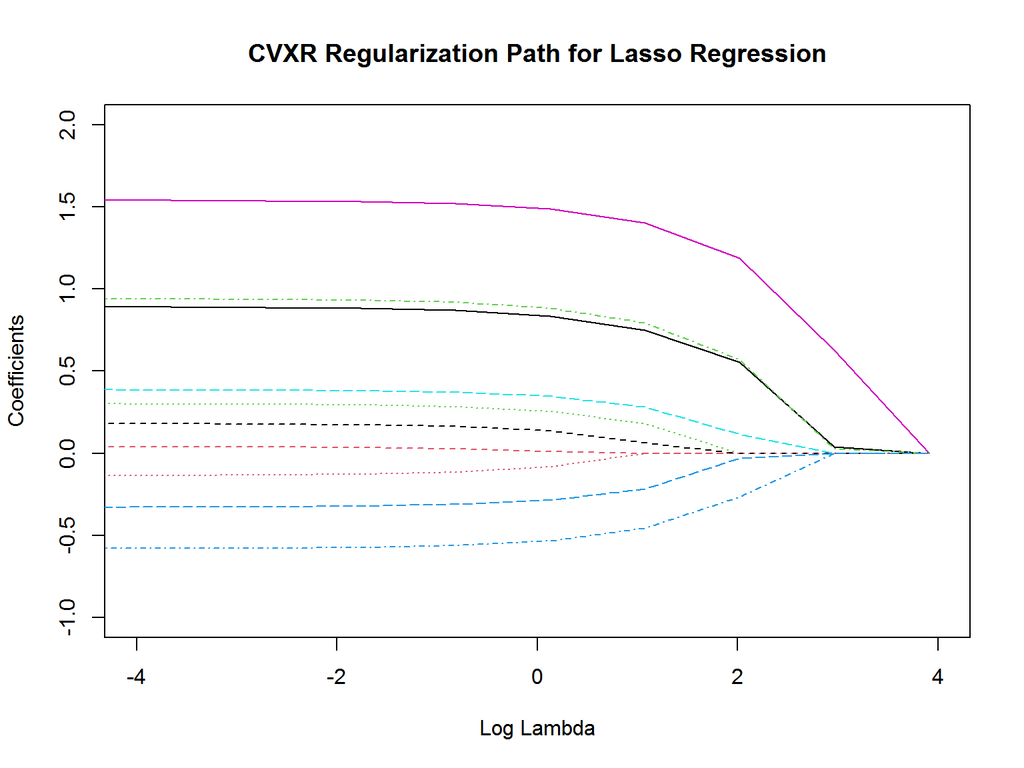

```r
plot(0, 0, type = "n", main = "CVXR Regularization Path for Lasso Regression",
     xlab = "Log Lambda", ylab = "Coefficients",
     ylim = c(-1, 2), xlim = c(-4, 4))
matlines(log(lambda_vals), t(beta_vals))
```

We then compare with the `glmnet` results.

```r
model_net <- glmnet(X, Y, family = "gaussian", alpha = alpha,
                    lambda = lambda_vals,
                    standardize = FALSE,
                    intercept = FALSE,
                    thresh = 1e-8)
## Reverse order to match beta_vals
coef_net <- as.data.frame(as.matrix(coef(model_net)[-1, seq(TRIALS, 1, by = -1)]))
```

|  | $\lambda = 0.010$ | $\lambda = 0.026$ | $\lambda = 0.066$ | $\lambda = 0.171$ | $\lambda = 0.441$ | $\lambda = 1.135$ | $\lambda = 2.924$ | $\lambda = 7.533$ | $\lambda = 19.408$ | $\lambda = 50.000$ |
| --- | --- | --- | --- | --- | --- | --- | --- | --- | --- | --- |
| $\beta_{1}$ | 0.891 | 0.890 | 0.888 | 0.883 | 0.870 | 0.836 | 0.747 | 0.553 | 0.038 | 0 |
| $\beta_{2}$ | 0.040 | 0.040 | 0.039 | 0.036 | 0.028 | 0.009 | 0.000 | 0.000 | 0.000 | 0 |
| $\beta_{3}$ | 0.301 | 0.300 | 0.299 | 0.294 | 0.283 | 0.254 | 0.181 | 0.000 | 0.000 | 0 |
| $\beta_{4}$ | -0.579 | -0.578 | -0.576 | -0.572 | -0.561 | -0.533 | -0.458 | -0.265 | 0.000 | 0 |
| $\beta_{5}$ | 0.386 | 0.385 | 0.384 | 0.380 | 0.371 | 0.347 | 0.283 | 0.114 | 0.000 | 0 |
| $\beta_{6}$ | 1.538 | 1.538 | 1.536 | 1.531 | 1.519 | 1.487 | 1.403 | 1.186 | 0.627 | 0 |
| $\beta_{7}$ | 0.181 | 0.180 | 0.178 | 0.174 | 0.163 | 0.136 | 0.065 | 0.000 | 0.000 | 0 |
| $\beta_{8}$ | -0.134 | -0.134 | -0.132 | -0.127 | -0.114 | -0.082 | 0.000 | 0.000 | 0.000 | 0 |
| $\beta_{9}$ | 0.939 | 0.938 | 0.936 | 0.931 | 0.918 | 0.885 | 0.794 | 0.570 | 0.026 | 0 |
| $\beta_{10}$ | -0.329 | -0.328 | -0.327 | -0.322 | -0.312 | -0.284 | -0.215 | -0.030 | 0.000 | 0 |

### Exercise

[A Stack Overflow Question](https://stats.stackexchange.com/questions/334007/elastic-net-in-glmnet-vs-cvxr)!

*I’m attempting to match some simple results in R using `glmnet` and `CVXR`. I have the following code.*

```r
library(glmnet)
data(QuickStartExample)
x <- QuickStartExample$x
y <- QuickStartExample$y
catn <- function(...) cat(..., "\n")
objective_value <- function(y, x, coefs, lambda, alpha) {
    n <- nrow(x)
    ridge <- sum(coefs^2) ; l1 <- sum(abs(coefs))
    sum((y - (x %*% coefs))^2) / (2 * n) + lambda * ((1 - alpha) / 2 * ridge + alpha * l1)
}
alpha  <- 0; lambda  <- 1;
fit <- glmnet(x, y, intercept=F, standardize=F, lambda=1, alpha=0)
```

```r
objective_value(y, x, coef(fit)[-1, ], lambda, alpha)
```

```
## [1] 2.573793
```

*but this `CVXR` code*

```r
beta <- Variable(20)
elastic_reg <- function(beta, lambda = 0, alpha = 0) {
   ridge <- (1 - alpha) * sum(beta^2) * .5
   lasso <- alpha * p_norm(beta, 1)
   lambda * (lasso + ridge)
}
loss <- sum((y - x %*% beta)^2)/(2*length(y))
obj <- loss + elastic_reg(beta, lambda = 1, 0)
prob <- Problem(Minimize(obj))
result <- solve(prob)
print(result$value)
```

```
## [1] 2.172438
```

#### Solution

To compare `glmnet` results to `CVXR` for the Gaussian case, it is advisable to standardize the response per the `glmnet` documentation. Note also that `glmnet` uses $n$ rather than $n-1$ in the denominator for $y$. This will ensure that the $\lambda$ is on the same scale as shown below.

```r
catn <- function(...) cat(..., "\n")
## Standardize the y
y_s <- local({
    n <- length(y)
    m <- mean(y); s <- as.numeric(sqrt(var(y) * (n - 1) / n));
    result <- (y - m) / s ## scale using 1/n
    attr(result, "scaled:center") <- m
    attr(result, "scaled:scale") <- s
    result
})
```

We can do a comparison on the standardized $y$. First, the `glmnet` answer:

```r
## STANDARDIZED COMPARISON
fit_s <- glmnet(x, y_s, intercept=F, standardize=F, lambda = lambda, alpha=alpha)
catn("Glmnet objective (scaled y)",
     objective_value(y_s, x, coef(fit_s)[-1], lambda, alpha))
```

```
## Glmnet objective (scaled y) 0.2504412
```

Next, the `CVXR` answer:

```r
elastic_reg <- function(beta, lambda = 0, alpha = 0) {
    ridge <- (1 - alpha) / 2 * sum_squares(beta)
    lasso <- alpha * p_norm(beta, 1)
    lambda * (lasso + ridge)
}
loss <- sum_squares(y_s - x %*% beta) / (2 * nrow(x))
obj <- loss + elastic_reg(beta, lambda = lambda, alpha)
prob <- Problem(Minimize(obj))
beta_est <- solve(prob)$getValue(beta)
catn("CVXR objective (scaled y):", objective_value(y_s, x, beta_est, lambda, alpha))
```

```
## CVXR objective (scaled y): 0.2504412
```

To work on the non-standardized scale, we need to match the `lamba` values as noted by the `glmnet` authors in Appendix 2 of the package vignette (Friedman, Hastie, and Tibshirani 2010).

```r
## NONSTANDARDIZED COMPARISON
fit <- glmnet(x, y, intercept=F, standardize=F, lambda = lambda, alpha=alpha)
catn("Glmnet objective (unscaled y)", objective_value(y, x, coef(fit)[-1], lambda, alpha))
```

```
## Glmnet objective (unscaled y) 2.573793
```

```r
loss <- sum_squares(y - x %*% beta) / (2 * nrow(x))
obj <- loss + elastic_reg(beta, lambda = lambda / attr(y_s, "scaled:scale"), alpha)
prob <- Problem(Minimize(obj))
beta_est <- solve(prob)$getValue(beta)
catn("CVXR objective (unscaled y)", objective_value(y, x, beta_est, lambda, alpha))
```

```
## CVXR objective (unscaled y) 2.559093
```

Finally, we can check that the coefficients are close enough.

```r
print_matrix(round(cbind(beta_est, coef(fit)[-1]), 3),
             row_names = sprintf("$\\beta_{%d}$", seq_len(20)),
             col_names = c("CVXR", "GLMNET"))
```

|  | CVXR | GLMNET |
| --- | --- | --- |
| $\beta_{1}$ | 1.117 | 1.123 |
| $\beta_{2}$ | 0.070 | 0.069 |
| $\beta_{3}$ | 0.568 | 0.571 |
| $\beta_{4}$ | 0.007 | 0.008 |
| $\beta_{5}$ | -0.683 | -0.687 |
| $\beta_{6}$ | 0.537 | 0.539 |
| $\beta_{7}$ | 0.121 | 0.121 |
| $\beta_{8}$ | 0.302 | 0.304 |
| $\beta_{9}$ | -0.075 | -0.074 |
| $\beta_{10}$ | 0.054 | 0.055 |
| $\beta_{11}$ | 0.143 | 0.144 |
| $\beta_{12}$ | -0.073 | -0.073 |
| $\beta_{13}$ | -0.029 | -0.029 |
| $\beta_{14}$ | -0.932 | -0.937 |
| $\beta_{15}$ | -0.077 | -0.078 |
| $\beta_{16}$ | 0.018 | 0.018 |
| $\beta_{17}$ | 0.008 | 0.007 |
| $\beta_{18}$ | 0.009 | 0.010 |
| $\beta_{19}$ | 0.031 | 0.031 |
| $\beta_{20}$ | -0.784 | -0.790 |

### Exercise

Using the data (`X`, `Y`) above, solve an elastic net problem with [Huber loss](https://cvxr.rbind.io/cvxr_functions/) using the Huber threshold $M = 0.5$.

#### Solution

Just set the loss as follows.

```r
beta <- Variable(p)
loss  <- sum(huber(Y - X %*% beta, M = 0.5))
## Elastic-net regression LASSO
alpha <- 1
beta_vals <- sapply(lambda_vals,
                    function (lambda) {
                        obj <- loss + elastic_penalty(beta, lambda, alpha)
                        prob <- Problem(Minimize(obj))
                        result <- solve(prob)
                        result$getValue(beta)
                    })
```

|  | $\lambda = 0.010$ | $\lambda = 0.026$ | $\lambda = 0.066$ | $\lambda = 0.171$ | $\lambda = 0.441$ | $\lambda = 1.135$ | $\lambda = 2.924$ | $\lambda = 7.533$ | $\lambda = 19.408$ | $\lambda = 50.000$ |
| --- | --- | --- | --- | --- | --- | --- | --- | --- | --- | --- |
| $\beta_{1}$ | 0.538 | 0.538 | 0.538 | 0.538 | 0.536 | 0.534 | 0.527 | 0.497 | 0.431 | 0.149 |
| $\beta_{2}$ | -0.371 | -0.371 | -0.371 | -0.371 | -0.370 | -0.370 | -0.369 | -0.352 | -0.351 | -0.147 |
| $\beta_{3}$ | 0.424 | 0.424 | 0.424 | 0.424 | 0.423 | 0.422 | 0.421 | 0.433 | 0.391 | 0.195 |
| $\beta_{4}$ | -0.874 | -0.874 | -0.874 | -0.874 | -0.873 | -0.873 | -0.871 | -0.871 | -0.798 | -0.638 |
| $\beta_{5}$ | -0.129 | -0.129 | -0.129 | -0.129 | -0.129 | -0.129 | -0.130 | -0.128 | -0.084 | 0.000 |
| $\beta_{6}$ | 1.233 | 1.233 | 1.233 | 1.233 | 1.233 | 1.232 | 1.230 | 1.237 | 1.155 | 0.828 |
| $\beta_{7}$ | -0.067 | -0.067 | -0.066 | -0.066 | -0.066 | -0.064 | -0.060 | -0.023 | -0.059 | 0.000 |
| $\beta_{8}$ | -0.590 | -0.590 | -0.590 | -0.590 | -0.589 | -0.586 | -0.580 | -0.559 | -0.494 | -0.116 |
| $\beta_{9}$ | 1.419 | 1.419 | 1.419 | 1.418 | 1.417 | 1.414 | 1.407 | 1.377 | 1.310 | 0.987 |
| $\beta_{10}$ | -0.266 | -0.266 | -0.266 | -0.266 | -0.266 | -0.265 | -0.265 | -0.255 | -0.225 | -0.069 |

# Nearly Isotonic Fits

## Goals

- Formulate nearly-isotonic and nearly-convex fits using `CVXR` atoms
- Use the bootstrap to estimate variance of approximation

### Nearly Isotonic Regression

Given a set of data points $y \in {\mathbf R}^m$, R. J. Tibshirani, Hoefling, and Tibshirani (2011) fit a nearly-isotonic approximation $\beta \in {\mathbf R}^m$ by solving

$$\begin{array}{ll}
\underset{\beta}{\mbox{minimize}} & \frac{1}{2}\sum_{i=1}^m (y_i - \beta_i)^2 + \lambda \sum_{i=1}^{m-1}(\beta_i - \beta_{i+1})_+,
\end{array}$$

where $\lambda \geq 0$ is a penalty parameter and $x_+ =\max(x,0)$. This can be directly formulated in `CVXR`.

### Global Warming Example

As an example, we use global warming data from the [Carbon Dioxide Information Analysis Center (CDIAC)](http://cdiac.ess-dive.lbl.gov/ftp/trends/temp/jonescru/). The data points are the annual temperature anomalies relative to the 1961–1990 mean.

```r
data(cdiac)
str(cdiac)
```

```
## 'data.frame':    166 obs. of  14 variables:
##  $ year  : int  1850 1851 1852 1853 1854 1855 1856 1857 1858 1859 ...
##  $ jan   : num  -0.702 -0.303 -0.308 -0.177 -0.36 -0.176 -0.119 -0.512 -0.532 -0.307 ...
##  $ feb   : num  -0.284 -0.362 -0.477 -0.33 -0.28 -0.4 -0.373 -0.344 -0.707 -0.192 ...
##  $ mar   : num  -0.732 -0.485 -0.505 -0.318 -0.284 -0.303 -0.513 -0.434 -0.55 -0.334 ...
##  $ apr   : num  -0.57 -0.445 -0.559 -0.352 -0.349 -0.217 -0.371 -0.646 -0.517 -0.203 ...
##  $ may   : num  -0.325 -0.302 -0.209 -0.268 -0.23 -0.336 -0.119 -0.567 -0.651 -0.31 ...
##  $ jun   : num  -0.213 -0.189 -0.038 -0.179 -0.215 -0.16 -0.288 -0.31 -0.58 -0.25 ...
##  $ jul   : num  -0.128 -0.215 -0.016 -0.059 -0.228 -0.268 -0.297 -0.544 -0.324 -0.285 ...
##  $ aug   : num  -0.233 -0.153 -0.195 -0.148 -0.163 -0.159 -0.305 -0.327 -0.28 -0.104 ...
##  $ sep   : num  -0.444 -0.108 -0.125 -0.409 -0.115 -0.339 -0.459 -0.393 -0.339 -0.575 ...
##  $ oct   : num  -0.452 -0.063 -0.216 -0.359 -0.188 -0.211 -0.384 -0.467 -0.2 -0.255 ...
##  $ nov   : num  -0.19 -0.03 -0.187 -0.256 -0.369 -0.212 -0.608 -0.665 -0.644 -0.316 ...
##  $ dec   : num  -0.268 -0.067 0.083 -0.444 -0.232 -0.51 -0.44 -0.356 -0.3 -0.363 ...
##  $ annual: num  -0.375 -0.223 -0.224 -0.271 -0.246 -0.271 -0.352 -0.46 -0.466 -0.286 ...
```

Since we plan to fit the regression and also get some idea of the standard errors, we write a function that computes the fit for use in bootstrapping.

```r
neariso_fit <- function(y, lambda) {
    m <- length(y)
    beta <- Variable(m)
    A <- as(m:1, "pMatrix") %*% Matrix::Diagonal(m)   # Matrix for reversing order
    obj <- 0.5 * sum_squares(y - beta) + lambda * sum(pos(diff(A %*% beta)))
    prob <- Problem(Minimize(obj))
    solve(prob)$getValue(beta)
}
```

Observe that we reverse the order of `beta` since `diff` outputs `beta[i+1] - beta[i]` for $i = 1,\ldots,m$. The `CVXR::pos` atom evaluates $x_+ = \max(x,0)$ elementwise on the input expression.

The `boot` library provides all the tools for bootstrapping, but requires a statistic function that takes particular arguments: a data frame, followed by the bootstrap indices and any other arguments ($\lambda$ for instance). This is defined below.

*NOTE*: In what follows, we use a very small number of bootstrap samples as the fits are time consuming.

```r
neariso_fit_stat <- function(data, index, lambda) {
    sample <- data[index,]                  # Bootstrap sample of rows
    sample <- sample[order(sample$year),]   # Order ascending by year
    neariso_fit(sample$annual, lambda)
}
```

```r
set.seed(123)
boot.neariso <- boot(data = cdiac,
                     statistic = neariso_fit_stat,
                     R = 10, lambda = 0.44)
ci.neariso <- t(sapply(seq_len(nrow(cdiac)),
                       function(i) boot.ci(boot.out = boot.neariso, conf = 0.95,
                                           type = "norm", index = i)$normal[-1]))
data.neariso <- data.frame(year = cdiac$year,
                           annual = cdiac$annual,
                           est = boot.neariso$t0,
                           lower = ci.neariso[, 1],
                           upper = ci.neariso[, 2])
```

We can now plot the fit and confidence bands for the nearly-isotonic fit.

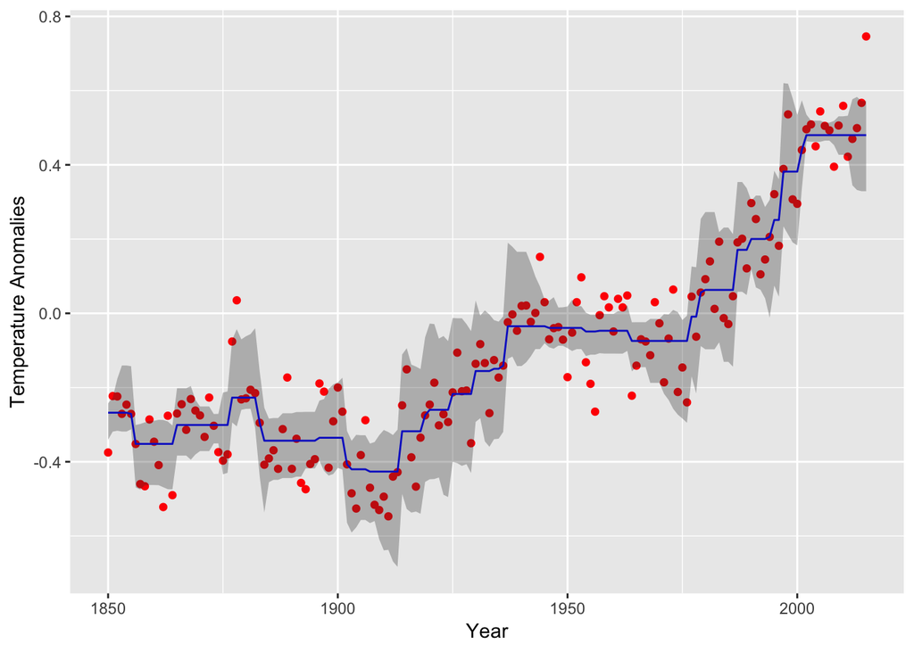

Nearly Isotonic Fit

```r
(plot.neariso <- ggplot(data = data.neariso) +
     geom_point(mapping = aes(year, annual), color = "red") +
     geom_line(mapping = aes(year, est), color = "blue") +
     geom_ribbon(mapping = aes(x = year, ymin = lower, ymax = upper), alpha = 0.3) +
     labs(x = "Year", y = "Temperature Anomalies")
)
```

The curve follows the data well, but exhibits some choppiness in regions with a steep trend.

### Exercise

Fit a smoother curve using a nearly-convex fit described in the same paper:

$$\begin{array}{ll}
\underset{\beta}{\mbox{minimize}} & \frac{1}{2}\sum_{i=1}^m (y_i -
\beta_i)^2 + \lambda \sum_{i=1}^{m-2}(\beta_i - 2\beta_{i+1} + \beta_{i+2})_+ \end{array}$$

#### Solution

This replaces the first difference term with an approximation to the second derivative at $\beta_{i+1}$. In `CVXR`, the only change necessary is the penalty line: replace `diff(A %*% x)` by `diff(A %*% x, differences = 2)`.

```r
nearconvex_fit <- function(y, lambda) {
    m <- length(y)
    beta <- Variable(m)
    A <- as(m:1, "pMatrix") %*% Matrix::Diagonal(m)   # Matrix for reversing order
    obj <- 0.5 * sum_squares(y - beta) + lambda * sum(pos(diff(A %*% beta, differences = 2)))
    prob <- Problem(Minimize(obj))
    solve(prob)$getValue(beta)
}

nearconvex_fit_stat <- function(data, index, lambda) {
    sample <- data[index,]                  # Bootstrap sample of rows
    sample <- sample[order(sample$year),]   # Order ascending by year
    nearconvex_fit(sample$annual, lambda)
}

set.seed(987)
boot.nearconvex <- boot(data = cdiac,
                        statistic = nearconvex_fit_stat,
                        R = 5,
                        lambda = 0.44)

ci.nearconvex <- t(sapply(seq_len(nrow(cdiac)),
                          function(i) boot.ci(boot.out = boot.nearconvex, conf = 0.95,
                                              type = "norm", index = i)$normal[-1]))
data.nearconvex <- data.frame(year = cdiac$year,
                              annual = cdiac$annual,
                              est = boot.nearconvex$t0,
                              lower = ci.nearconvex[, 1],
                              upper = ci.nearconvex[, 2])
```

The resulting curve for the nearly-convex fit is depicted below with 95% confidence bands generated from $R = 5$ samples. Note the jagged staircase pattern has been smoothed out.

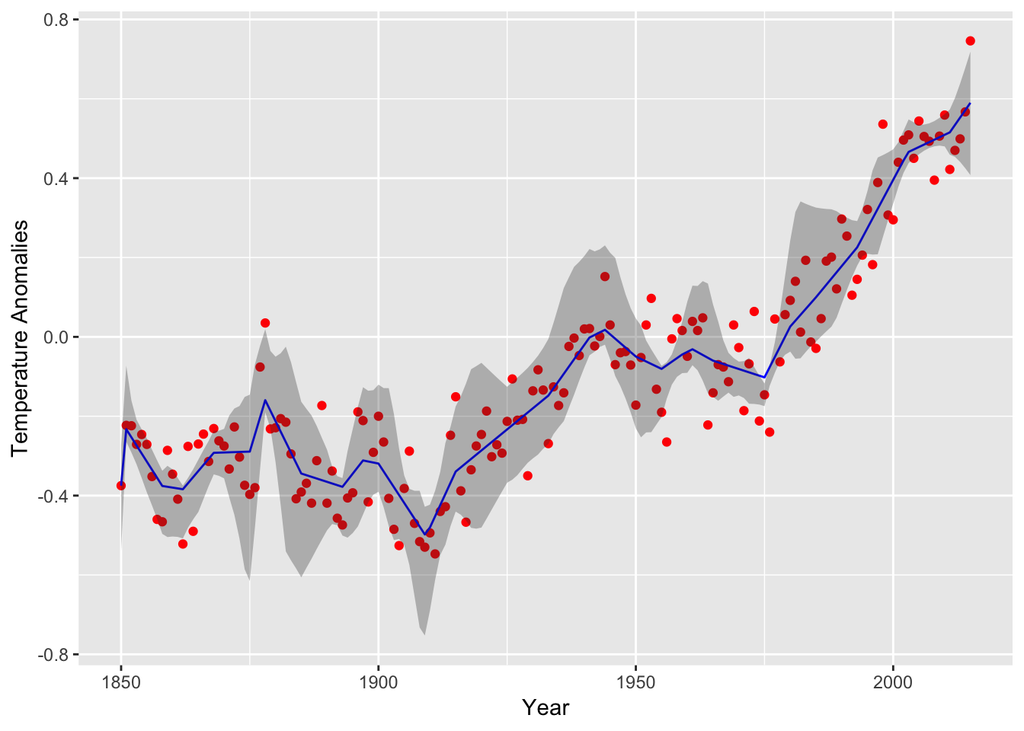

Nearly Convex Fit

```r
(plot.nearconvex <- ggplot(data = data.nearconvex) +
     geom_point(mapping = aes(year, annual), color = "red") +
     geom_line(mapping = aes(year, est), color = "blue") +
     geom_ribbon(mapping = aes(x = year, ymin = lower, ymax = upper), alpha = 0.3) +
     labs(x = "Year", y = "Temperature Anomalies")
)
```

This is a smoother fit as can be seen

# Speed Considerations

## Note

The material in this section was written for `CVXR` pre 1.0. It no longer applies to versions 1.0 and above. Indeed `CVXR` is actually much faster now by default. We will update this section for 1.0 as appropriate later.

# Pliable Lasso

## Goals

- Demonstrate how to fit a complex model
- Show how to apply an atom along a row/column axis

## Pliable Lasso Problem

Robert J. Tibshirani and Friedman (2017) propose a generalization of the lasso that allows the model coefficients to vary as a function of a general set of modifying variables, such as gender, age, and time. The pliable lasso model has the form

$$\begin{equation}
\hat{y} = \beta_0{\mathbf 1} + Z\theta_0 + \sum_{j=1}^p(X_j\beta_j +
W_j\theta_j),
\end{equation}$$

where $\hat{y}$ is the predicted $N\times1$ vector, $\beta_0$ is a scalar, $\theta_0$ is a $K$-vector, $X$ and $Z$ are $N\times p$ and $N\times K$ matrices containing values of the predictor and modifying variables, respectively, and $W_j=X_j \circ Z$ denotes the elementwise multiplication of $Z$ by column $X_j$ of $X$.

The objective function used for pliable lasso is

$$J(\beta_0, \theta_0, \beta, \Theta) =
\frac{1}{2N}\sum_{i=1}^N (y_i-\hat{y}_i)^2 +
(1-\alpha)\lambda\sum_{j=1}^p\biggl(||(\beta_j,\theta_j)||_2 +
||\theta_j||_2\biggr) + \alpha\lambda\sum_{j,k}|\theta_{j,k}|_1.$$

In the above, $\Theta$ is a $p\times K$ matrix of parameters with $j$-th row $\theta_j$ and individual entries $\theta_{j,k}$, and $\alpha$ and $\lambda$ are tuning parameters. As $\alpha \rightarrow 1$ (but $<1$), the solution approaches the lasso solution. The default value used in the paper is $\alpha = 0.5.$

An R package for the pliable lasso is currently archived on [CRAN](https://CRAN.R-project.org/package=pliable). Nevertheless, the pliable lasso is an excellent example to highlight the prototyping capabilities of `CVXR` for research. Along the way, we also introduce some new atoms that are needed in this example.

## Example

We will use a simulated example from Section 3 of Robert J. Tibshirani and Friedman (2017) with $n=100$, $p=50$ and $K=4$. The response is generated as

$$\begin{eqnarray*}
y &=& \mu(x) + 0.5\epsilon;\ \ \epsilon \sim N(0, 1)\\
\mu(x) &=& x_1\beta_1 + x_2\beta_2 + x_3(\beta_3 e + 2z_1) +
x_4\beta_4(e - 2z_2);\ \ \beta = (2, -2, 2, 2, 0, 0,\ldots),
\end{eqnarray*}$$
where $e=(1,1,\ldots,1)^T$.

```r
## Simulation data.
set.seed(123)
N <- 100
K <- 4
p <- 50
X <- matrix(rnorm(n = N * p, mean = 0, sd = 1), nrow = N, ncol = p)
Z <- matrix(rbinom(n = N * K, size = 1, prob = 0.5), nrow = N, ncol = K)

## Response model.
beta <- rep(x = 0, times = p)
beta[1:4] <- c(2, -2, 2, 2)
coeffs <- cbind(beta[1], beta[2], beta[3] + 2 * Z[, 1], beta[4] * (1 - 2 * Z[, 2]))
mu <- diag(X[, 1:4] %*% t(coeffs))
y <- mu + 0.5 * rnorm(N, mean = 0, sd = 1)
```

It seems worthwhile to write a function that will fit the model for us so that we can customize a few things such as the intercept term, verbosity, etc. The function has the following structure with comments as placeholders for code we shall construct later.

```r
plasso_fit <- function(y, X, Z, lambda, alpha = 0.5, intercept = TRUE,
                       ZERO_THRESHOLD= 1e-6, verbose = FALSE) {
    N <- length(y)
    p <- ncol(X)
    K <- ncol(Z)

    beta0 <- 0
    if (intercept) {
        beta0 <- Variable(1) * matrix(1, nrow = N, ncol = 1)
    }
    ## Define_Parameters
    ## Build_Penalty_Terms
    ## Compute_Fitted_Value
    ## Build_Objective
    ## Define_and_Solve_Problem
    ## Return_Values
}

## Fit pliable lasso using CVXR.
# pliable <- pliable_lasso(y, X, Z, alpha = 0.5, lambda = lambda)
```

### Variables

The variables are easy: we just have $\beta$, $\theta_0$, and $\Theta$.

```r
beta <- Variable(p)
theta0 <- Variable(K)
theta <- Variable(p, K); theta_transpose <- t(theta)
```

Note that we also define the transpose of $\Theta$ for use later.

### Penalty Terms

There are three of them. The first term in the parentheses, $\sum_{j=1}^p\biggl(||(\beta_j,\theta_j)||_2\biggr)$, involves components of $\beta$ and rows of $\Theta$. `CVXR` provides two functions to express this norm:

- `hstack` to bind columns of $\beta$ and the matrix $\Theta$, the equivalent of `cbind` in R,
- `cvxr_norm`, which accepts a matrix variable and an `axis` denoting the axis along which the norm is to be taken. The penalty requires us to use the row axis, so `axis = 1` per the usual R convention.

The second term in the parentheses, $\sum_{j}||\theta_j||_2$, is also a norm along rows as the $\theta_j$ are rows of $\Theta$. The last term is simply a $l_1$-norm.

```r
penalty_term1 <- sum(cvxr_norm(hstack(beta, theta), 2, axis = 1))
penalty_term2 <- sum(cvxr_norm(theta, 2, axis = 1))
penalty_term3 <- sum(cvxr_norm(theta, 1))
```

### Fitted Value

The equation for $\hat{y}$ contains a sum: $\sum_{j=1}^p(X_j\beta_j + W_j\theta_j)$. This requires multiplication of $Z$ by the columns of $X$ component-wise and is thus a natural candidate for a map-reduce combination: map the column multiplication function appropriately and reduce using `+` to obtain the `XZ_term` below.

```r
xz_theta <- lapply(seq_len(p),
                   function(j) (matrix(X[, j], nrow = N, ncol = K) * Z) %*% theta_transpose[, j])
XZ_term <- Reduce(f = '+', x = xz_theta)
y_hat <- beta0 + X %*% beta + Z %*% theta0 + XZ_term
```

### Objective Function

Building the objective is now straightforward.

```r
objective <- sum_squares(y - y_hat) / (2 * N) +
    (1 - alpha) * lambda * (penalty_term1 + penalty_term2) +
    alpha * lambda * penalty_term3
```

### Solving the Problem

```r
prob <- Problem(Minimize(objective))
result <- solve(prob, verbose = verbose)
beta_hat <- result$getValue(beta)
```

### Return Values

We create a list with values of interest to us. However, since sparsity is desired, we set values below `ZERO_THRESHOLD` to zero.

```r
theta0_hat <- result$getValue(theta0)
theta_hat <- result$getValue(theta)

## Zero out stuff before returning
beta_hat[abs(beta_hat) < ZERO_THRESHOLD] <- 0.0
theta0_hat[abs(theta0_hat) < ZERO_THRESHOLD] <- 0.0
theta_hat[abs(theta_hat) < ZERO_THRESHOLD] <- 0.0
list(beta0_hat = if (intercept) result$getValue(beta0)[1] else 0.0,
     beta_hat = beta_hat,
     theta0_hat = theta0_hat,
     theta_hat = theta_hat,
     criterion = result$value)
```

## Full Function

We now put it all together.

```r
plasso_fit <- function(y, X, Z, lambda, alpha = 0.5, intercept = TRUE,
                          ZERO_THRESHOLD = 1e-6, verbose = FALSE) {
    N <- length(y)
    p <- ncol(X)
    K <- ncol(Z)

    beta0 <- 0
    if (intercept) {
        beta0 <- Variable(1) * matrix(1, nrow = N, ncol = 1)
    }
    beta <- Variable(p)
    theta0 <- Variable(K)
    theta <- Variable(p, K); theta_transpose <- t(theta)
    penalty_term1 <- sum(cvxr_norm(hstack(beta, theta), 2, axis = 1))
    penalty_term2 <- sum(cvxr_norm(theta, 2, axis = 1))
    penalty_term3 <- sum(cvxr_norm(theta, 1))
    xz_theta <- lapply(seq_len(p),
                       function(j) (matrix(X[, j], nrow = N, ncol = K) * Z) %*% theta_transpose[, j])
    XZ_term <- Reduce(f = '+', x = xz_theta)
    y_hat <- beta0 + X %*% beta + Z %*% theta0 + XZ_term
    objective <- sum_squares(y - y_hat) / (2 * N) +
        (1 - alpha) * lambda * (penalty_term1 + penalty_term2) +
        alpha * lambda * penalty_term3
    prob <- Problem(Minimize(objective))
    result <- solve(prob, verbose = verbose)
    beta_hat <- result$getValue(beta)
    theta0_hat <- result$getValue(theta0)
    theta_hat <- result$getValue(theta)

    ## Zero out stuff before returning
    beta_hat[abs(beta_hat) < ZERO_THRESHOLD] <- 0.0
    theta0_hat[abs(theta0_hat) < ZERO_THRESHOLD] <- 0.0
    theta_hat[abs(theta_hat) < ZERO_THRESHOLD] <- 0.0
    list(beta0_hat = if (intercept) result$getValue(beta0)[1] else 0.0,
         beta_hat = beta_hat,
         theta0_hat = theta0_hat,
         theta_hat = theta_hat,
         criterion = result$value)
}
```

## Results

Using $\lambda = 0.6$, we fit the pliable lasso without an intercept.

```r
result <- plasso_fit(y, X, Z, lambda = 0.6, alpha = 0.5, intercept = FALSE)
```

We can print the various estimates.

```r
cat(sprintf("Objective value: %f\n", result$criterion))
```

```
## Objective value: 4.153289
```

We only print the nonzero $\beta$ values.

```r
index <- which(result$beta_hat != 0)
est.table <- data.frame(matrix(result$beta_hat[index], nrow = 1))
names(est.table) <- paste0("$\\beta_{", index, "}$")
knitr::kable(est.table, format = "html", digits = 3) %>%
    kable_styling("striped")
```

| $\beta_{1}$ | $\beta_{2}$ | $\beta_{3}$ | $\beta_{4}$ | $\beta_{20}$ |
| --- | --- | --- | --- | --- |
| 1.716 | -1.385 | 2.217 | 0.285 | -0.038 |

For this value of $\lambda$, the nonzero $(\beta_1, \beta_2, \beta_3,\beta_4)$ are picked up along with an additional $\beta_{20}$.

The values for $\theta_0$ are given below.

```r
est.table <- data.frame(matrix(result$theta0_hat, nrow = 1))
names(est.table) <- paste0("$\\theta_{0,", 1:K, "}$")
knitr::kable(est.table, format = "html", digits = 3) %>%
    kable_styling("striped")
```

| $\theta_{0,1}$ | $\theta_{0,2}$ | $\theta_{0,3}$ | $\theta_{0,4}$ |
| --- | --- | --- | --- |
| -0.136 | 0.25 | -0.516 | 0.068 |

Finally, we display just the first five rows of $\Theta$, which happen to contain all the nonzero values for this result.

```r
est.table <- data.frame(result$theta_hat[1:5, ])
names(est.table) <- paste0("$\\theta_{,", 1:K, "}$")
knitr::kable(est.table, format = "html", digits = 3) %>%
    kable_styling("striped")
```

| $\theta_{,1}$ | $\theta_{,2}$ | $\theta_{,3}$ | $\theta_{,4}$ |
| --- | --- | --- | --- |
| 0.000 | 0.000 | 0.000 | 0.000 |
| 0.000 | 0.000 | 0.000 | 0.000 |
| 0.528 | 0.000 | 0.085 | 0.308 |
| 0.063 | -0.592 | -0.019 | -0.185 |
| 0.000 | 0.000 | 0.000 | 0.000 |

## Final Comments

Typically, one would run the fits for various values of $\lambda$, choose one based on cross-validation, and assess the prediction against a test set. Here, even a single fit takes a while. However, the potential of `CVXR` in prototyping novel methods is clear.

# Survey Calibration

Calibration is a widely used technique in survey sampling. Suppose $m$ sampling units in a survey have been assigned initial weights $d_i$ for $i = 1,\ldots,m$, and furthermore, there are $n$ auxiliary variables whose values in the sample are known. Calibration seeks to improve the initial weights $d_i$ by finding new weights $w_i$ that incorporate this auxiliary information while perturbing the initial weights as little as possible, i.e., the ratio $g_i = w_i/d_i$ must be close to one. Such reweighting improves precision of estimates (Chapter 7, T. S. Lumley (2010)).

Let $X \in {\mathbf R}^{m \times n}$ be the matrix of survey samples, with each column corresponding to an auxiliary variable. Reweighting can be expressed as the optimization problem (see Davies, Gillard, and Zhigljavsky (2016)):

$$\begin{array}{ll}
\mbox{minimize} & \sum_{i=1}^m d_i\phi(g_i) \\
\mbox{subject to} & A^Tg = r
\end{array}$$

with respect to $g \in {\mathbf R}^m$, where $\phi:{\mathbf R} \rightarrow {\mathbf R}$ is a strictly convex function with $\phi(1) = 0$, $r \in {\mathbf R}^n$ are the known population totals of the auxiliary variables, and $A \in {\mathbf R}^{m \times n}$ is related to $X$ by $A_{ij} = d_iX_{ij}$ for $i = 1,\ldots,m$ and $j = 1,\ldots,n$.

## Raking

A common calibration technique is *raking*, which uses the penalty function $\phi(g_i) = g_i\log(g_i) - g_i + 1$ as the calibration metric.

We illustrate this with the California Academic Performance Index data in the `survey` package (T. Lumley (2018)), which also supplies facilities for calibration via the function `calibrate`. Both the population dataset (`apipop`) and a simple random sample of $m = 200$ (`apisrs`) are provided. Suppose that we wish to reweight the observations in the sample using known totals for two variables from the population: `stype`, the school type (elementary, middle, or high) and `sch.wide`, whether the school met the yearly target or not. This reweighting would make the sample more representative of the general population.

The code below estimates the weights using `survey::calibrate`.

```r
data(api)
design_api <- svydesign(id = ~dnum, weights = ~pw, data = apisrs)
formula <- ~stype + sch.wide
T <- apply(model.matrix(object = formula, data = apipop),
           2,
           sum)

cal_api <- calibrate(design_api, formula, population = T, calfun = cal.raking)
w_survey <- weights(cal_api)
```

The `CVXR` formulation follows.

```r
di <- apisrs$pw
X <- model.matrix(object = formula, data = apisrs)
A <- di * X
n <- nrow(apisrs)
g <- Variable(n)
constraints <- list(t(A) %*% g == T)

## Raking
Phi_R <- Minimize(sum(di * (-entr(g) - g + 1)))
p <- Problem(Phi_R, constraints)
res <- solve(p)
w_cvxr <- di * res$getValue(g)
```

The results are identical as shown in the table below.

Calibration weights from Raking

| stype | sch.wide | Survey wts. | Frequency | CVXR wts. | Frequency |
| --- | --- | --- | --- | --- | --- |
| E | No | 28.911 | 15 | 28.911 | 15 |
| E | Yes | 31.396 | 127 | 31.396 | 127 |
| H | No | 29.003 | 13 | 29.003 | 13 |
| H | Yes | 31.497 | 12 | 31.497 | 12 |
| M | No | 29.033 | 9 | 29.033 | 9 |
| M | Yes | 31.529 | 24 | 31.529 | 24 |

### Exercise

The quadratic penalty function

$$\phi^{Q}(g) = \frac{1}{2}(g-1)^2$$

is also sometimes used. Calibrate using `CVXR` and the `SCS` solver and compare with the `survey::cal.linear` results, which can be obtained via

```r
w_survey_q <- weights(calibrate(design_api, formula, population = T, calfun = cal.linear))
```

#### Solution

```r
## Quadratic
Phi_Q  <- Minimize(sum_squares(g - 1) / 2)
p <- Problem(Phi_Q, constraints)
res <- solve(p, solver = "SCS")
w_cvxr_q <- di * res$getValue(g)
```

The default `OSQP` solver produces a different number of unique weights. Such differences are not unheard of among solvers.

Calibration weights from Quadratic metric

[output not shown]

### Exercise

Repeat the above exercise with the logistic function

$$\phi^{L}(g; l, u) = \frac{1}{C}\biggl[ (g-l)\log\left(\frac{g-l}{1-l}\right) +
(u-g)\log\left(\frac{u-g}{u-1}\right) \biggr] \mbox{ for } C = \frac{u-l}{(1-l)(u-1)},$$

which requires bounds $l$ and $u$ on the coefficients. Use $l=0.9$ and $u=1.1$. The results from `survey::cal.linear` can be obtained with the code below.

```r
u <- 1.10; l <- 0.90
w_survey_l <- weights(calibrate(design_api, formula, population = T, calfun = cal.linear,
                                bounds = c(l, u)))
```

### Solution

```r
Phi_L <- Minimize(sum(-entr((g - l) / (u - l))  -
                      entr((u - g) / (u - l))))
p <- Problem(Phi_L, c(constraints, list(l <= g, g <= u)))
res <- solve(p)
w_cvxr_l <- di * res$getValue(g)
```

Calibration weights from Logit metric

| stype | sch.wide | Survey wts. | Frequency | CVXR wts. | Frequency |
| --- | --- | --- | --- | --- | --- |
| E | No | 28.907 | 15 | 28.929 | 15 |
| E | Yes | 31.397 | 127 | 31.394 | 127 |
| H | No | 29.005 | 13 | 28.995 | 13 |
| H | Yes | 31.495 | 12 | 31.505 | 12 |
| M | No | 29.037 | 9 | 29.014 | 9 |
| M | Yes | 31.528 | 24 | 31.536 | 24 |

### Exercise

Repeat with the Hellinger distance

$$\Phi^{H}(g) = \frac{1}{(1 - g/2)^2}$$

and the following results.

```r
hellinger <- make.calfun(Fm1 = function(u, bounds)  ((1 - u / 2)^-2) - 1,
                         dF= function(u, bounds) (1 -u / 2)^-3 ,
                         name = "Hellinger distance")
w_survey_h <- weights(calibrate(design_api, formula, population = T, calfun = hellinger))
```

#### Solution

```r
Phi_h <- Minimize(sum((1 - g / 2)^(-2)))
p <- Problem(Phi_h, constraints)
res <- solve(p)
w_cvxr_h <- di * res$getValue(g)
```

Calibration weights from Hellinger distance metric

| stype | sch.wide | Survey wts. | Frequency | CVXR wts. | Frequency |
| --- | --- | --- | --- | --- | --- |
| E | No | 28.913 | 15 | 28.890 | 15 |
| E | Yes | 31.396 | 127 | 31.399 | 127 |
| H | No | 29.002 | 13 | 29.011 | 13 |
| H | Yes | 31.498 | 12 | 31.488 | 12 |
| M | No | 29.031 | 9 | 29.056 | 9 |
| M | Yes | 31.530 | 24 | 31.521 | 24 |

### Exercise

Lastly, use the derivative of the inverse hyperbolic sine

$$\Phi^{S}(g) = \frac{1}{2}(e^g + e^{-g})$$

along with the results produced below.

```r
w_survey_s <- weights(calibrate(design_api, formula, population = T, calfun = cal.sinh,
                                bounds = c(l, u)))
```

#### Solution

```r
Phi_s <- Minimize(sum( 0.5 * (exp(g) + exp(-g))))
p <- Problem(Phi_s, c(constraints, list(l <= g, g <= u)))
res <- solve(p)
w_cvxr_s <- di * res$getValue(g)
```

Calibration weights from derivative of sinh metric

| stype | sch.wide | Survey wts. | Frequency | CVXR wts. | Frequency |
| --- | --- | --- | --- | --- | --- |
| E | No | 28.911 | 15 | 28.904 | 15 |
| E | Yes | 31.396 | 127 | 31.397 | 127 |
| H | No | 29.003 | 13 | 29.006 | 13 |
| H | Yes | 31.497 | 12 | 31.494 | 12 |
| M | No | 29.033 | 9 | 29.041 | 9 |
| M | Yes | 31.529 | 24 | 31.526 | 24 |

# Sparse Inverse Covariance Estimation

## Goals

- Introduce positive semidefinite matrices and `CVXR::log_det`
- Demonstrate how to build functions for complex tasks

## Sparse Inverse Covariance Problem

Assume we are given i.i.d. observations $x_i \sim N(0,\Sigma)$ for $i = 1,\ldots,m$, where the covariance matrix $\Sigma \in {\mathbf S}_+^n$, the set of symmetric positive semidefinite matrices, has a sparse inverse $S = \Sigma^{-1}$. Let $Q = \frac{1}{m-1}\sum_{i=1}^m (x_i - \bar x)(x_i - \bar x)^T$ be our sample covariance. One way to estimate $\Sigma$ is to maximize the log-likelihood with the prior knowledge that $S$ is sparse (Friedman, Hastie, and Tibshirani 2008), which amounts to the optimization problem:

$$\begin{array}{ll} \mbox{maximize} & \log\det(S) - \mbox{tr}(SQ) \\
\mbox{subject to} & \sum_{i=1}^n \sum_{j=1}^n |S_{ij}| \leq \alpha
\end{array}$$
with respect to $S \in {\mathbf S}_+^n$, where the parameter $\alpha \geq 0$ controls the degree of sparsity. The problem is convex, so we can solve it using `CVXR`.

## Example

We’ll create a sparse positive semidefinite matrix $S$ using synthetic data.

```r
set.seed(1)
n <- 10      ## Dimension of matrix
m <- 1000    ## Number of samples

## Create sparse, symmetric PSD matrix S
A <- rsparsematrix(n, n, 0.15, rand.x = stats::rnorm)
Strue <- A %*% t(A) + 0.05 * diag(rep(1, n))    ## Force matrix to be strictly positive definite
```

We then invert $S$ to get $R = S^{-1}$.

```r
R <- base::solve(Strue)
```

As test data, we sample from a multivariate normal distribution using the fact that if $Y \sim N(0, I)$, then $R^{1/2}Y \sim N(0, R)$ since $R$ is symmetric.

```r
x_sample <- matrix(stats::rnorm(n * m), nrow = m, ncol = n) %*% t(expm::sqrtm(R))
Q <- cov(x_sample)    ## Sample covariance matrix
```

Finally, we solve our convex program for a range of $\alpha$ values.

```r
alphas <- c(10, 8, 6, 4, 1)
S <- Variable(n, n, PSD = TRUE)    ## Variable constrained to positive semidefinite cone
obj <- Maximize(log_det(S) - matrix_trace(S %*% Q))

S.est <- lapply(alphas,
                function(alpha) {
                    constraints <- list(sum(abs(S)) <= alpha)
                    ## Form and solve optimization problem
                    prob <- Problem(obj, constraints)
                    result <- solve(prob)

                    ## Create covariance matrix
                    R_hat <- base::solve(result$getValue(S))
                    Sres <- result$getValue(S)
                    Sres[abs(Sres) <= 1e-4] <- 0
                    Sres
                })
```

In the code above, the `PSD = TRUE` argument to the `Variable` constructor restricts `S` to the positive semidefinite cone. We use `CVXR` functions for the log-determinant and trace in the objective. The expression `matrix_trace(S %*% Q)` is equivalent to `sum(diag(S %*% Q))}`, but the former is preferred because it is more efficient than making nested function calls.

However, a standalone atom does not exist for the determinant, so we cannot replace `log_det(S)` with `log(det(S))` since `det` is undefined for a `Variable` object.

## Results

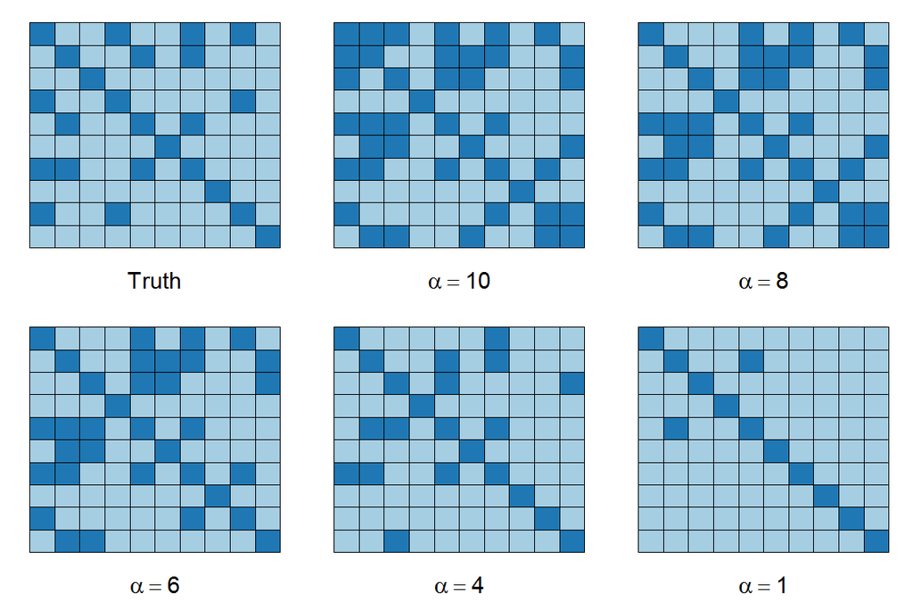

```r
do.call(multiplot, args = c(list(plotSpMat(Strue)),
                            mapply(plotSpMat, S.est, alphas, SIMPLIFY = FALSE),
                            list(layout = matrix(1:6, nrow = 2, byrow = TRUE))))
```

# Portfolio Estimation

The Markowitz portfolio problem (Markowitz 1952; Roy 1952; Lobo, Fazel, and Boyd 2007) is well known in finance. We will solve this problem under various constraints.

We have $n$ assets or stocks in our portfolio and must determine the amount of money to invest in each. Let $w_i$ denote the fraction of our budget invested in asset $i = 1,\ldots,m$, and let $r_i$ be the returns (i.e., fractional change in price) over the period of interest. We model returns as a random vector $r \in {\mathbf R}^n$ with known mean $\mathbf{E}[r] = \mu$ and covariance $\mathbf{Var}(r) = \Sigma$. Thus, given a portfolio $w \in {\mathbf R}^n$, the overall return is $R = r^Tw$.

Portfolio optimization involves a trade-off between the expected return $\mathbf{E}[R] = \mu^Tw$ and the associated risk, which we take to be the return variance $\mathbf{Var}(R) = w^T\Sigma w$. Initially, we consider only long portfolios, so our problem is
$$\begin{array}{ll}
\underset{w}{\mbox{maximize}} & \mu^Tw - \gamma w^T\Sigma w \\
\mbox{subject to} & w \geq 0, \quad \sum_{i=1}^n w_i = 1,
\end{array}$$
where the objective is the risk-adjusted return and $\gamma > 0$ is a risk aversion parameter.

## Example

We construct the risk-return trade-off curve for $n = 10$ assets and $\mu$ and $\Sigma^{1/2}$ drawn from a standard normal distribution.

```r
## Problem data
set.seed(10)
n <- 10
SAMPLES <- 100
mu <- matrix(abs(rnorm(n)), nrow = n)
Sigma <- matrix(rnorm(n^2), nrow = n, ncol = n)
Sigma <- t(Sigma) %*% Sigma

## Form problem
w <- Variable(n)
ret <- t(mu) %*% w
risk <- quad_form(w, Sigma)
constraints <- list(w >= 0, sum(w) == 1)

## Risk aversion parameters
gammas <- 10^seq(-2, 3, length.out = SAMPLES)
ret_data <- rep(0, SAMPLES)
risk_data <- rep(0, SAMPLES)
w_data <- matrix(0, nrow = SAMPLES, ncol = n)

## Compute trade-off curve
for(i in seq_along(gammas)) {
    gamma <- gammas[i]
    objective <- ret - gamma * risk
    prob <- Problem(Maximize(objective), constraints)
    result <- solve(prob)

    ## Evaluate risk/return for current solution
    risk_data[i] <- result$getValue(sqrt(risk))
    ret_data[i] <- result$getValue(ret)
    w_data[i,] <- result$getValue(w)
}
```

Note how we obtain the risk and return by *directly evaluating* the value of the separate expressions:

```r
result$getValue(risk)
result$getValue(ret)
```

## Results

The trade-off curve is shown below. The $x$-axis represents the standard deviation of the return. Red points indicate the result from investing the entire budget in a single asset. As $\gamma$ increases, our portfolio becomes more diverse, reducing risk but also yielding a lower return.

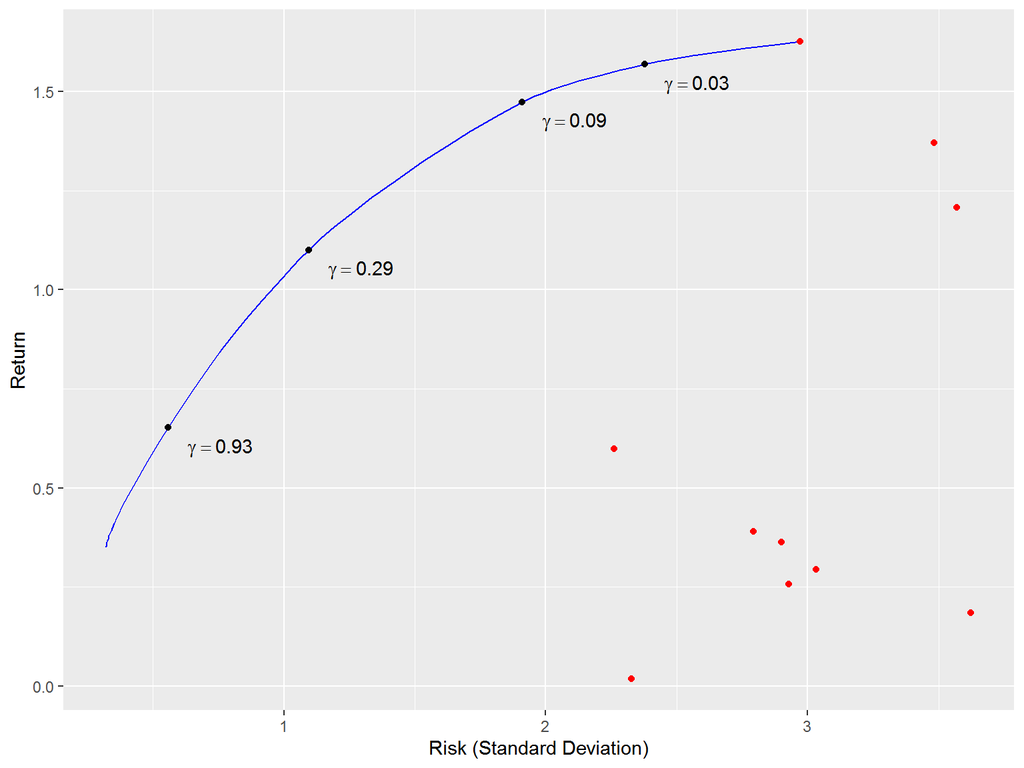

```r
cbPalette <- brewer.pal(n = 10, name = "Paired")
p1 <- ggplot() +
    geom_line(mapping = aes(x = risk_data, y = ret_data), color = "blue") +
    geom_point(mapping = aes(x = sqrt(diag(Sigma)), y = mu), color = "red")

markers_on <- c(10, 20, 30, 40)
nstr <- sprintf("gamma == %.2f", gammas[markers_on])
df <- data.frame(markers =  markers_on, x = risk_data[markers_on],
                 y = ret_data[markers_on], labels = nstr)

p1 + geom_point(data = df, mapping = aes(x = x, y = y), color = "black") +
    annotate("text", x = df$x + 0.2, y = df$y - 0.05, label = df$labels, parse = TRUE) +
    labs(x = "Risk (Standard Deviation)", y = "Return")
```

We can also plot the fraction of budget invested in each asset.

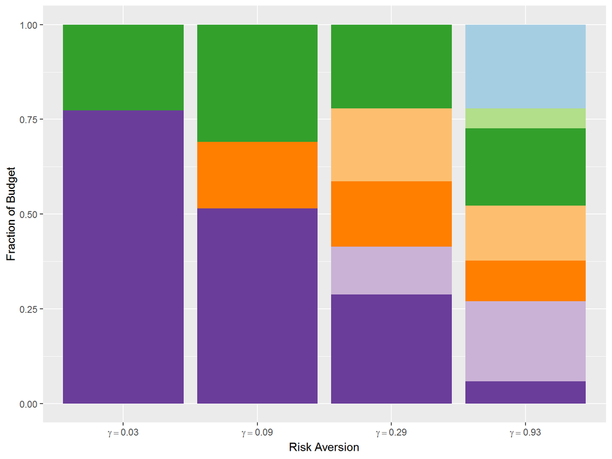

```r
w_df <- data.frame(paste0("grp", seq_len(ncol(w_data))),
                   t(w_data[markers_on,]))
names(w_df) <- c("grp", sprintf("gamma == %.2f", gammas[markers_on]))
tidyW <- gather(w_df, key = "gamma", value = "fraction", names(w_df)[-1], factor_key = TRUE)
ggplot(data = tidyW, mapping = aes(x = gamma, y = fraction)) +
    geom_bar(mapping = aes(fill = grp), stat = "identity") +
    scale_x_discrete(labels = parse(text = levels(tidyW$gamma))) +
    scale_fill_manual(values = cbPalette) +
    guides(fill = "none") +
    labs(x = "Risk Aversion", y = "Fraction of Budget")
```

## Discussion

Many variations on the classical portfolio problem exist. For instance, we could allow long and short positions, but impose a leverage limit $\|w\|_1 \leq L^{max}$ by changing

```r
constr <- list(p_norm(w,1) <= Lmax, sum(w) == 1)
```

An alternative is to set a lower bound on the return and minimize just the risk. To account for transaction costs, we could add a term to the objective that penalizes deviations of $w$ from the previous portfolio. These extensions and more are described in Boyd et al. (2017).

The key takeaway is that all of these convex problems can be easily solved in `CVXR` with just a few alterations to the code above.

# Using Other Solvers

## Goals

- Show how to use non-default solvers like `MOSEK` and `GUROBI`
- Discuss solver peculiarities

## Default Solvers

The default installation of `CVXR` comes with three (imported) open source solvers:

- [ECOS](https://github.com/embotech/ecos) and its mixed integer cousin `ECOS_BB` via the CRAN package ECOSolveR
- [SCS](https://github.com/cvxgrp/scs) via the CRAN package scs.
- [OSQP](https://osqp.org/) via the CRAN package osqp.

`CVXR` can also make use of several other open source solvers implemented in R packages.

- The linear and mixed integer programming package [`lpSolve`](http://lpsolve.sourceforge.net/5.5/) via the [`lpSolveAPI`](https://cloud.r-project.org/package=lpSolveAPI) package
- The linear and mixed integer programming package [`GLPK`](https://www.gnu.org/software/glpk/) via the [`Rglpk`](https://cloud.r-project.org/package=Rglpk) package.

Since these are optional, you must install the packages yourself.

```r
lapply(list(LPSOLVE = "lpSolveAPI",
            GLPK = "Rglpk"),
       function(x) x %in% installed.packages()[, 1])
```

```
## $LPSOLVE
## [1] TRUE
##
## $GLPK
## [1] TRUE
```

Once the packages are installed, a call to `installed_solvers` will display the solvers that `CVXR` has detected.

## Commercial Solvers

A few commercial solvers are also currently supported: [MOSEK](https://www.mosek.com) and [GUROBI](https://www.gurobi.com).

`CVXR` version 1.0 directly calls these solvers via their associated R packages using [*problem reductions*](https://web.stanford.edu/~boyd/papers/cvxpy_rewriting.html). (Previous `CVXR` versions required Python and the [`reticulate`](https://cran.r-project.org/package=reticulate) package).

### Installing `MOSEK`

[MOSEK](https://www.mosek.com) provides an academic version that is free of charge. As noted in the downloads page, Anaconda users can install merely via:

```bash
conda install -c mosek mosek
```

Others can use the `pip` command:

```bash
pip install -f https://download.mosek.com/stable/wheel/index.html Mosek
```

In addition, the license for the product has to be activated per instructions on the `Sales` section of the MOSEK web page. The [Rmosek](https://docs.mosek.com/9.2/rmosek/install-interface.html) R package must be installed separately.

Once activated, you can check that `CVXR` recognizes the solver; `installed_solvers()` should list `MOSEK`. Otherwise, rinse and repeat until success.

### Installing `GUROBI`

[GUROBI](https://www.gurobi.com) also provides an academic version that is free of charge. You must register to receive the license.

Once registered, install the *Gurobi Optimizer* software and activate your license as necessary. The [gurobi](https://www.gurobi.com/documentation/9.1/refman/ins_the_r_package.html) R package must be installed separately.

After activation, you can check that `CVXR::installed_solvers()` lists `GUROBI`. Otherwise, rinse and repeat until success.

### Gotchas

If you have an Anaconda installation in your path, you have to account for the fact that there may be interactions when using RStudio and rendering documents. In particular, Anaconda may include its own version of pandoc and other tools that may conflict with what RStudio needs to work properly.

To be concrete, one problem we found was that the `MOSEK` solver was not recognized as available in this rendered document, even though the command line interface showed it to be present. Ensuring an appropriate `PATH` variable solves the problem.

### Example Session

```r
installed_solvers()
```

```
## [1] "ECOS"    "ECOS_BB" "GLPK_MI" "GLPK"    "SCS"     "GUROBI"  "MOSEK"
## [8] "OSQP"
```

## Solver Peculiarities

The most commonly used solver in `CVXR` is `ECOS`. However, it is not always the best solver for a problem. As an example, let us consider again the catenary problem.

We will change the problem slightly to use a finer discretization from 101 to 501 points.

```r
## Problem data
m <- 501
L <- 2
h <- L / (m - 1)

## Form objective
x <- Variable(m)
y <- Variable(m)
objective <- Minimize(sum(y))

## Form constraints
constraints <- list(x[1] == 0, y[1] == 1,
                    x[m] == 1, y[m] == 1,
                    diff(x)^2 + diff(y)^2 <= h^2)

## Solve the catenary problem
prob <- Problem(objective, constraints)
result <- solve(prob, solver = "ECOS")
```

The solution status is no longer optimal.

```r
cat("Solution status is", result$status)
```

```
## Solution status is optimal_inaccurate
```

In such cases, using a different solver may give more accurate results. Let us try `MOSEK`.

```r
if ("MOSEK" %in% installed_solvers()) {
    result <- solve(prob, solver = "MOSEK")
    cat("Solution status is", result$status)
} else {
    cat("Solution not available as MOSEK is not installed!")
}
```

```
## Solution status is optimal
```

This returns an optimal solution.

Here again, even commercial solvers differ; `GUROBI`, for example, does not completely solve the problem and in fact throws an error.

# The Structure of Atoms

## Goals

- Understand the S4 class structure of an atom
- Derive the canonicalization of the quadratic-over-linear function
- Follow `CVXR`’s transformation of a problem to solver-ingestible form

`CVXR` comes with a rich library of atoms that represent common functions in convex analysis. When combined using the DCP rules, these atoms are sufficient to model and solve most convex optimization problems, and we encourage most users to work with the `CVXR` library. However, it is possible for a sophisticated user to add a new atom. To do this requires an understanding of mathematical programming and the S4 class system. In this guide, we go over the basics of implementing an atom, the quadratic-over-linear function, which should provide a starting point for potential developers.

## Definition

For any $x \in \mathbf{R}^n$ and $y \in \mathbf{R}$, the quadratic-over-linear (QoL) function is

$$f(x,y) := \frac{\|x\|_2^2}{y} \quad \mbox{with} \quad \mathbf{dom}\;f = \{(x,y) \in \mathbf{R}^n \times \mathbf{R}: y > 0\}.$$

In `CVXR`, atoms like this (along with variables, constraints, etc) are represented by S4 class objects. S4 allows us to overload standard mathematical operations so `CVXR` combines seamlessly with native R script and other packages. The class for the QoL function is `QuadOverLin`, defined as

```r
setClass("QuadOverLin", representation(x = "ConstValORExpr", y = "ConstValORExpr"), contains = "Atom")
```

We also provide a constructor

```r
quad_over_lin <- function(x, y) { new("QuadOverLin", x = x, y = y) }
```

The `QuadOverLin` class inherits from the `Atom` superclass. It takes as input two arguments, `x` and `y`, which must be R numeric constants or `CVXR` `Expression` objects. These input types are encapsulated in the “ConstaValORExpr” class union. Since `Expression`s themselves may contain other atoms, this allows us to use the QoL function in nested compositions.

During initialization, `x` and `y` must be passed to the `Atom` superclass for processing and validation. Consequently, we override the default `QuadOverLin` initialization method with

```r
setMethod("initialize", "QuadOverLin", function(.Object, ..., x, y) {
  .Object@x <- x
  .Object@y <- y
  callNextMethod(.Object, ..., args = list(.Object@x, .Object@y))
})
```

The first two lines save `x` and `y` to their respective slots in `QuadOverLin`, while the third calls `Atom`’s `initialize` with `args` equal to the list of arguments. For explanatory purposes, we reproduce this method below.

```r
setMethod("initialize", "Atom", function(.Object, ..., args = list(), .size = NA_real_) {
  .Object@args <- lapply(args, as.Constant)
  validate_args(.Object)
  .Object@.size <- size_from_args(.Object)
  callNextMethod(.Object, ...)
})
```

It is not important to understand the details of the above code. Only recognize that the atom arguments are converted into `CVXR` objects and saved in a list in the `args` slot. We will be accessing this slot later.

## Atom Properties

Now that we have created the atom’s S4 class, it is time to define methods that characterize its mathematical properties.

### Mathematical Basics

First, we provide a method for validating the atom’s inputs. This method is called in `initialize` to check whether the arguments make sense for the atom. For our function $f$, the second argument must be a scalar, so our validation method looks like

```r
setMethod("validate_args", "QuadOverLin", function(object) {
  if(!is_scalar(object@args[[2]]))
    stop("[QuadOverLin: validation] y must be a scalar")
})
```

The input `object` is a `QuadOverLin` atom. We access its arguments via its `args` slot inherited from `Atom`. Given our ordering in `args`, we know `object@args[[1]]` contains the argument for $x$ and `object@args[[2]]` the one for $y$. Hence, we invoke `is_scalar`, an `Expression` class method, on the latter to check if $y$ is indeed scalar. If this check passes, then a call is made up the stack to `validate_args` in `Atom`.

Notice that we did not check whether $y > 0$. This is because we generally do not know the value of an argument at the time of construction. For instance, `y` may contain a `Variable` that we are solving for in a problem, and we cannot define the problem if validation fails. It is the user’s responsibility to include domain constraints during problem construction.

To facilitate this, we define a method for that that returns a list of `Constraint` objects delineating an atom’s domain. For the QoL function, we need only constrain its second argument to be positive. Strict inequalities are not supported in `CVXR`, so we impose a weak inequality $y \geq 0$ as shown below.

```r
setMethod(".domain", "QuadOverLin", function(object) { list(object@args[[2]] >= 0) })
```

Both validation and domain methods may be dropped if an atom’s arguments span the reals.

The `to_numeric` method is always required. It takes as input an atom and a list `values` containing the numeric values of its arguments (given in the same order as in `args`), then evaluates the atom at these values. For the QoL function, this method is simply

```r
setMethod("to_numeric", "QuadOverLin", function(object, values) { sum(values[[1]]^2) / values[[2]] })
```

Note the difference between `object@args` and `values`. The former is a list of `Expression`s, which represent a composition of constants, variables, and atoms. The latter is a list of R numeric constants like `numeric` and `matrix`, denoting the values of the corresponding expressions.

### Dimension, Sign, and Curvature

For DCP analysis to work, we must explicitly define each atom’s dimension, sign, and curvature. `CVXR` uses this information when applying the composition rules to an expression. It is easy to see that $f$ is scalar-valued, nonnegative, and convex over its domain. These properties are encoded in

```r
setMethod("size_from_args", "QuadOverLin", function(object) { c(1,1) })
setMethod("sign_from_args",  "QuadOverLin", function(object) { c(TRUE, FALSE) })
setMethod("is_atom_convex", "QuadOverLin", function(object) { TRUE })
setMethod("is_atom_concave", "QuadOverLin", function(object) { FALSE })
```

Here, the `sign_from_args` function returns a vector of two logical values - the first indicates if the atom’s value is positive, and the second if it is negative.

We also define whether the atom is weakly increasing or decreasing in each of its arguments. By taking derivatives, we find that $f$ is weakly decreasing in $y$, weakly increasing in $x$ on $\mathbf{R}_+^n$, and weakly decreasing in $x$ on $\mathbf{R}_-^n$. These properties are spelled out in

```r
setMethod("is_incr", "QuadOverLin", function(object, idx) { (idx == 1) && is_positive(object@args[[idx]]) })
setMethod("is_decr", "QuadOverLin", function(object, idx) { ((idx == 1) && is_negative(object@args[[idx]])) || (idx == 2) })
```

where `idx` is the index of the argument of interest (`idx = 1` for `x` and `idx = 2` for `y`). We call the `Expression` class method `is_positive` (resp. `is_negative`) to determine if an argument is nonnegative (resp. nonpositive). The user may be tempted to write `object@args[[idx]] >= 0`, but this is **incorrect** because it returns a `Constraint` rather than a logical value.

### Additional Characteristics

The methods we have just described are the bare minimum required to define an atom. Additional methods may be implemented that provide further functional characterization. For instance, we furnish a method for computing the gradient of the QoL function,

$$\nabla_x f(x,y) = \frac{2x}{y}, \quad \nabla_y f(x,y) = -\frac{\|x\|_2^2}{y^2},$$

at a point $(x,y)$.

```r
setMethod(".grad", "QuadOverLin", function(object, values) {
  X <- values[[1]]
  y <- as.numeric(values[[2]])
  if(y <= 0)
    return(list(NA_real_, NA_real_))
  else {
    # DX = 2X/y, Dy = -||X||^2_2/y^2
    Dy <- -sum(X^2)/y^2
    Dy <- Matrix(Dy, sparse = TRUE)
    DX <- 2.0*X/y
    DX <- Matrix(as.numeric(t(DX)), sparse = TRUE)
    return(list(DX, Dy))
  }
})
```

This method calculates the vectors $\nabla_x f(x,y)$ and $\nabla_y f(x,y))$, wraps each in a sparse `Matrix`, and returns them in a list ordered exactly as in the input values. If $(x,y) \notin \mathbf{dom}\;f$, all gradients are set to `NA`.

## Canonicalization

Once `CVXR` verifies a problem is DCP, it converts that problem into a solver-compatible form. This *canonicalization* process is carried out through a series of calls to individual atom canonicalizers. To implement an atom, we must explicitly derive its canonicalizer for a conic program. Below we provide a derivation based on the graph implementation.

A function $g: \mathbf{R}^n \rightarrow \mathbf{R}$ is convex if and only if its epigraph

$$\mathbf{epi}\;g = \{(x,t) \in \mathbf{R}^n \times \mathbf{R}: g(x) \leq t\}$$
is a convex set. Then, it can be written as
$$g(x) = \inf \{t \in \mathbf{R}: (x,t) \in \mathbf{epi}\;g \}.$$

A similar relationship holds between concave functions and their hypographs. The *graph implementation* of a function is a representation of its epigraph or hypograph as a disciplined convex feasibility problem. This offers an elegant means of defining a nondifferentiable function in terms of a canonical optimization problem, which can be directly evaluated by a solver.

For instance, the QoL function can be written as a second-order cone program (SOCP). Given $(x,y) \in \mathbf{dom}\;f$, the inequality $f(x,y) \leq t$ is equivalent to

$$\begin{align*}
4\|x\|_2^2 &\leq 4ty = (y+t)^2 - (y-t)^2 \\
(y-t)^2 + \|2x\|_2^2 &\leq (y+t)^2 \\
\left\|\begin{pmatrix} y-t \\ 2x \end{pmatrix}\right\|_2 &\leq y+t
\end{align*}$$
so that
$$f(x,y) = \inf \left\{t \in \mathbf{R}: \left(\begin{pmatrix} y-t \\ 2x \end{pmatrix}, y+t\right) \in \mathcal{K} \right\},$$
where $\mathcal{K} := \{(u,v) \in \mathbf{R}^{n+1} \times \mathbf{R}: \|u\|_2 \leq v\}$ is a second-order cone. Thus, $f(x,y)$ is the solution to an SOCP, which may be evaluated using any conic solver. The canonicalizer for the QoL function takes as input $(x,y)$ and outputs the above SOCP.

In `CVXR`, this canonicalizer function is defined as

```r
QuadOverLin.graph_implementation <- function(arg_objs, size, data = NA_real_) {
  x <- arg_objs[[1]]
  y <- arg_objs[[2]]   # Known to be a scalar.
  t <- create_var(c(1,1))
  two <- create_const(2, c(1,1))
  constraints <- list(SOC(lo.sum_expr(list(y, t)),
                          list(lo.sub_expr(y, t),
                               lo.mul_expr(two, x, x$size))),
                      create_geq(y))
  list(t, constraints)
}
```

It takes as input a list of arguments `arg_objs`, which specify the input values $(x,y)$, the `size` of the resulting expression, and a list of additional `data` required by the atom. The first two lines of the function extract $x$ and $y$ from `args`, the third line constructs the `Variable` $t \in \mathbf{R}$, and the fourth line defines the constant $2$. The fifth line forms the constraint $\left(\begin{pmatrix} y-t \\ 2x \end{pmatrix}, y+t\right) \in \mathcal{K}$ with a call to the constructor `SOC`. If $u \in \mathbf{R}^n$, then `SOC(t,u)` enforces $\|u\|_2 \leq t$. Finally, the canonicalizer returns a list containing $t$, the epigraph variable, and a list of `Constraint`s from the graph implementation - in this case, the second-order cone constraint and $y \geq 0$.

## Putting It All Together

With this machinery in place, we are ready to use the `QuadOverLin` atom in a problem. Suppose we are given $A \in \mathbf{R}^{m \times n}$ and $b \in \mathbf{R}^m$, and we would like to solve

$$\begin{array}{ll}
\mbox{minimize} & f(x,y) \\
\mbox{subject to} & Ax = b
\end{array}$$

with respect to $x \in \mathbf{R}^n$ and $y \in \mathbf{R}_{++}$. In `CVXR`, we write

```r
x <- Variable(n)
y <- Variable()
obj <- quad_over_lin(x,y)
constr <- c(domain(obj), A %*% x == b)
prob <- Problem(Minimize(obj), constr)
solve(prob)
```

Once `solve` is invoked, `CVXR` checks if the problem is DCP with calls to `is_atom_convex`, `is_incr`, and `is_decr` for each atom in the expression tree. It then converts the problem as modeled to a form compatible with the desired solver.

In our example, this requires a transformation into a cone program. Substituting in the graph implementation of $f$, our original problem can be written as

$$\begin{array}{ll}
\mbox{minimize} & t \\
\mbox{subject to} & Ax = b, \quad (x,y) \in \mathbf{dom}\;f, \quad \left(\begin{pmatrix} y-t \\ 2x \end{pmatrix}, y+t\right) \in \mathcal{K},
\end{array}$$

where $t \in \mathbf{R}$ is the additional epigraph variable. If $b \in \mathbf{null}\;A$, a solution is trivially $x^{\star} = \vec{0}$ with any $y^{\star} > 0$. Otherwise, the point $y = 0$ is infeasible, so we can relax the domain constraint to get

$$\begin{array}{ll}
\mbox{minimize} & t \\
\mbox{subject to} & Ax = b, \quad y \geq 0, \quad \left(\begin{pmatrix} y-t \\ 2x \end{pmatrix}, y+t\right) \in \mathcal{K}.
\end{array}$$

In `CVXR`, this SOCP canonicalization is performed automatically via a call to `QuadOverLin.graph_implementation`. Then, the relevant matrices are formed and passed to the selected conic solver. After the solver returns $(x^{\star},y^{\star},t^{\star})$, the transformation is reversed to obtain the optimal point $(x^{\star},y^{\star})$ and objective value $f(x^{\star},y^{\star})$ for the original problem.

# Future Enhancements

## Version 1.1

- Higher dimensional variables
- New atoms and transformations
  - Support function
  - Scalar product
  - Matrix multiplication for DGP
- Disciplined parametrized programming (DPP)
- System for differentiating the map from a problem’s parameters to its solution (Agrawal et al. 2019)

## Internal Changes

- Uniform interface for solver settings
- Speed improvements by moving operations to C++
- Possibly connect to `ROI` library

# References

Agrawal, A., B. Amos, S. Barratt, S. Boyd, S. Diamond, and J. Zico Kolter. 2019. “Differentiable Convex Optimization Layers.” In *Advances in Neural Information Processing Systems*, 9958–9570.

Boyd, S., E. Busseti, S. Diamond, R. N. Kahn, K. Koh, P. Nystrup, and J. Speth. 2017. “Multi-Period Trading via Convex Optimization.” *Foundations and Trends in Optimization*.

Davies, G., J. Gillard, and A. Zhigljavsky. 2016. “Comparative Study of Different Penalty Functions and Algorithms in Survey Calibration.” In *Advances in Stochastic and Deterministic Global Optimization*, 87–127. Cham: Springer-Verlag. https://doi.org/10.1007/978-3-319-29975-4_6.

de Leeuw, J., K. Hornik, and P. Mair. 2009. “Isotone Optimization in R: Pool-Adjacent-Violators Algorithm (PAVA) and Active Set Methods.” *Journal of Statistical Software* 32 (5): 1–24.

Friedman, J., T. Hastie, and R. Tibshirani. 2008. “Sparse Inverse Covariance Estimation with the Graphical Lasso.” *Biostatistics* 9 (3): 432–41.

———. 2010. “Regularization Paths for Generalized Linear Models via Coordinate Descent.” *Journal of Statistical Software* 33 (1): 1–22.

Fu, A., B. Narasimhan, and Stephen Boyd. 2020. “CVXR: An R Package for Disciplined Convex Optimization.” *Journal of Statistical Software (to Appear)* 94 (14): 1–34. https://doi.org/10.18637/jss.v094.i14.

H. Zou, T. Hastie. 2005. “Regularization and Variable Selection via the Elastic–Net.” *Journal of the Royal Statistical Society B (Methodological)* 67 (2): 301–20.

James, Gareth, Daniela Witten, Trevor Hastie, and Robert Tibshirani. 2013. *An Introduction to Statistical Learning: With Applications in R*. Springer Texts in Statistics. Springer New York. https://doi.org/10.1007/978-1-4614-7138-7.

Lobo, M. S., M. Fazel, and S. Boyd. 2007. “Portfolio Optimization with Linear and Fixed Transaction Costs.” *Annals of Operations Research* 152 (1): 341–65.

Lumley, Thomas. 2018. “survey: Analysis of Complex Survey Samples.”

Lumley, Thomas S. 2010. *Complex Surveys: A Guide to Analysis Using r*. John Wiley & Sons.

Markowitz, H. M. 1952. “Portfolio Selection.” *Journal of Finance* 7 (1): 77–91.

Roy, A. D. 1952. “Safety First and the Holding of Assets.” *Econometrica* 20 (3): 431–49.

Tibshirani, R. J., H. Hoefling, and R. Tibshirani. 2011. “Nearly-Isotonic Regression.” *Technometrics* 53 (1): 54–61.

Tibshirani, Robert J., and Jerome H. Friedman. 2017. “A Pliable Lasso.” *arXiv Preprint Arxiv:1712.00484*. https://arxiv.org/abs/1712.00484.